# Wild plants of primary lowland tropical rain forest

Malcolm Ross

## 1. Introduction

This chapter focuses principally on the lowland tropical rain forests of New Britain and New Ireland, the large islands of the Bismarck Archipelago, as these are the forests whose margins - at the very least - would have been familiar to Proto Oceanic (POc) speakers. It would be appropriate also to include the rain forests of the Admiralties, but little is known about them (World Wildlife Fund 2007a). Some attention is also given to the other islands of NW Island Melanesia, namely Bougainville and the Solomons, as they were occupied by speakers of early Oceanic dialects which were perhaps barely distinct from POc.

Also included here are trees which grow in freshwater swamp forest, a habitat that is not common in the Bismarcks, though more widespread in Bougainville and parts of the Solomons (ch.2, §3.1.3). Excluded are (i) plants that mainly occur in littoral forest (see chapter 5) and (ii) plants that occur in the wild but are also tended or cultivated to some degree (see chapters 9-11 and 13).

In POc times, the Bismarcks would have been almost completely covered in rain forest, and much of their area remained so until 30 years ago, although there were of course substantial portions of secondary forest resulting from the agricultural activities of Oceanic speakers over 3000 years (ch.2, §3.2).[^1]:

Although New Britain and New Ireland have two distinct soil types, one limestone-based, the other volcanic, there is surprisingly little difference in their species composition. Major lowland rain forest tree genera include Pometia, *Octomeles*, *Alstonia*, Campnosperma, *Canarium*, *Dracontomelon*, *Pterocymbium*, Crytocarya, Intsia, *Ficus*, *Terminalia* and *Vitex*.

Compared with mainland New Guinea the overall diversity of tree species in Bismarcks lowland forests is not impressive. Missing are the two conifers *Araucaria hunsteinii* and *Araucaria cunninghamii* that tower above the lowland broadleaf forests in New Guinea. The dipterocarps (Dipterocarpaceae) that dominate much of peninsular and island southeast Asia are represented by only three species in New Guinea, and probably not at all in the Bismarcks (World Wildlife Fund 2007b).

Freshwater swamp forests on New Britain and New Ireland include Campnosperma brevipetiolata (§4.1), *Terminalia brassii*, the sago palm (*Metroxylon sagu*), and species of *Pandanus*. Limestone forests near the coast of southern New Ireland and along the coast and interior of New Britain are dominated by *Vitex cofassus* (World Wildlife Fund 2007b).

## 2. Rain forest layers

A rain forest typically has four or five layers (opinions differ on the division of the lower layers), and these provided the basis for the organisation of this chapter.[^2]:

The tallest trees, spaced well apart, jut out above the forest canopy with umbrella-shaped crowns at heights of over 50 m. These **emergent trees**, treated in §3, have straight, smooth trunks with few branches. They need to be able to withstand high temperatures and drying winds and tend to have small, pointed leaves. Some species lose their leaves during the brief dry season in monsoon rainforests.

The **canopy** (§4) contains a majority of the larger trees, typically 30–50 m tall, and its adjacent treetops provide a more or less continuous cover of broad-leaved evergreen foliage. The branches of the upper portion of the canopy often support a rich flora of epiphytes, including orchids, mosses, and lichens. The canopy receives plenty of sunlight, but allows only a small amount to penetrate to the layers below. The leaves are formed in such a way as to allow rain to run off. This keeps them dry and prevents mold and mildew from forming in the humid environment. Many canopy tree species have large buttresses at the base of the trunk. Formerly believed to help support the tree, it is now believed that the buttresses channel dissolved nutrients to the shallow root system.

The **understorey** has two parts: a **lower canopy** (§5) consisting of trees around 20m in height and a **shrub layer** (§6) of small trees, shrubs, herbs and ferns able to survive on the 5% of sunlight which reaches the understorey. Understorey plants tend to have large leaves in order to catch as much as possible of the sparsely dappled sunlight: they are largely protected from winds which would damage large leaves in the canopy. Some trees have larger leaves when they are shorter but smaller leaves when they reach canopy height. Large woody vines climb the trees to capture sunlight. There is little air movement and constantly high humidity in the understorey.

The **forest floor** (§7) receives only 2% of the rainforest’s sunlight, and only specially adapted plants can grow under these conditions. Away from river banks, swamps and clearings, where dense undergrowth is found, the forest floor is relatively empty of vegetation. It also contains decaying plant and animal matter, which decays rapidly in the warmth and humidity to be absorbed by the trees’ shallow roots. Many forms of fungi grow here, assisting in the decay.

## 3. Emergent trees

Emergent trees are those which regularly grow to 50 m or more. There are also a number of canopy trees that grow taller and acquire emergent status in some localities. These are noted in the various subsections of §4.

### 3.1. *Alstonia scholaris*, milky pine, canoe tree, TP *kanu* (Apocynaceae)

*Alstonia scholaris* is an emergent or tall canopy tree, growing straight to a height of 30–50 m or more, with few branches on its trunk. It grows only in the forest, often near rivers (Hviding 2005: 146). It is a salient tree in the Bismarcks and the Solomons, but it is rare in Remote Oceania, probably because its use there in constructing large canoes has put the survival of at least taller specimens under pressure (W. McClatchey, pers. comm.).

The straight trunk with its lightweight wood is used in many locations for making canoes, for beams, for shark-trap and fishing-net floats and for carving (Powell 1976, Peekel 1984: 441, Hviding 2005: 146). At Teop (north Bougainville), the tree is known simply as *sinivi* ‘canoe’ (Record 1945). Wood from buttresses was used for the tall prows of Marovo war canoes.

On New Britain the latex is said to relieve colds (Floyd 1954). At Marovo the sap or bark scrapings boiled in water is a medicine for stomach ache.

At Marovo too, the dead were commonly buried in a sitting position between the buttresses of *Alstonia scholaris*, and so it was associated with the departure of the spirits of the dead, resulting in taboos against felling it.

A PMP form for ‘*Alstonia scholaris*’, namely *ditah, is reconstructable (ACD), but I have found no Oceanic reflexes of this. Despite their apparent variation, the reflexes of POc *sabakap below are largely regular. Kara, Patpatar and Nehan reflect regular loss of *-k- but retain the final consonant. NNG languages, Nakanai and SES languages lose the final consonant. The Choiseul languages Varisi, Avaso, Ririo, Babatana and Sisingga reflect Proto Northwest Solomonic *baɣava (for †*abaɣava) in which initial *s- is lost through lenition (a sporadic process) and the final consonant is retained with the addition of an echo vowel.

| **POc** |  | *sabakap | ‘*Alstonia scholaris*’ (Chowning 2001: 84) |
| --- | --- | --- | --- |
| NNG | Longeinga | *samvaga* | ‘*Alstonia scholaris*’ (Panoff 1972) |
| NNG | Kairiru | *sabok* | ‘*Alstonia scholaris*’ |
| MM | Nakanai | *sabaka* | ‘*Alstonia* sp.’ |
| MM | East Kara | *savəf* | ‘*Alstonia scholaris*’ (*-f* unexplained) |
| MM | Patpatar | *sabau* | ‘*Alstonia scholaris*’ (*-u* unexplained) |
| MM | Nehan | *habau* | ‘*Alstonia scholaris*’ (*-u* unexplained) |
| MM | Varisi | *baɣava* | ‘*Alstonia scholaris*’ (W. McClatchey, pers. comm.) |
| MM | Avasö | *boava* | ‘*Alstonia scholaris*’ (W. McClatchey, pers. comm.) |
| MM | Ririo | *boʔo* | ‘*Alstonia scholaris*’ (W. McClatchey, pers. comm.) |
| MM | Babatana | *bua* | ‘*Alstonia scholaris*’ (W. McClatchey, pers. comm.) |
| MM | Sisiqa | *baɣava* | ‘*Alstonia scholaris*’ (W. McClatchey, pers. comm.) |
| SES | Gela | *habaga* | ‘*Alstonia scholaris*’ |
| SES | Kwaio | *tabaʔa* | ‘*Alstonia scholaris*’ |
| SES | Kwara’ae | *tabaʔa* | ‘*Alstonia scholaris*’ |
| SES | Ulawa | *tabaʔa* | ‘*Alstonia scholaris*’ |

### 3.2. *Falcataria moluccana* (syn. *Albizia falcataria*, *Albizia moluccana*, *Albizia falcata*, *Paraserianthes falcataria*) (Mimosaceae)

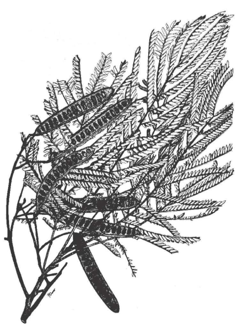

**Figure 7.1:** *Falcataria moluccana*.

*Falcataria moluccana* was until recently known as *Albizia falcataria*. Because there are items in the data glossed ‘*Albizia* sp.’ which may in fact denote *Falcataria moluccana*, the genera *Falcataria* and *Albizia* are handled together here.

The small-leafed crown of *Falcataria moluccana* emerges above all other trees in Bismarcks rain forests. It grows to between 30 and 60 m in height with a trunk up to 1 m in diameter (Peekel 1984: 207-208), but it is brittle and can come crashing to the ground (W. McClatchey, pers. comm.).

On New Britain and on Manus its trunk is used for canoe hulls, on New Britain also for slitgongs (Powell 1976, Arentz et al. 1989: 94, O’Collins & Lamothe 1989). However, McClatchey points out that it does not serve these purposes well, as objects made from it don’t last. It is more likely to be given to learner carvers or canoe-makers for practice.

The reconstruction of a term (or terms) for *Falcataria moluccana* is difficult. Kwa’ioloa & Burt (2001: 107), discussing the similar *Albizia salomonensis* on Malaita, say that it only grows close to rivers and prefers sandy soils. If the same is true of *Falcataria moluccana*, then its occurrence in Bismarcks rain forests three thousand years ago may have been rather rare, resulting in the frequent loss of inherited terms for the species. Alternatively, the fact that it has little use may account for the dearth of cognates (ch.14, §2).

All three reconstructions below entail uncertainties. POc *babak has just two reflexes. With regard to POc *pail and *kai(k), POc vowel sequences like *-ai- were fairly rare, and it is possible that *q intervened between *a and *i, but *-q- is reflected in none of the modern languages nor in the CMP cognates which support the reconstruction of PCEMP *bail[^3]: and *ka(w)iak.[^4]: The latter is reconstructed with an uncertain medial *-w-*, reflected in E Sumba *kawia[ka]*. If *-w-* was present at an earlier stage, it is irregularly lost in Nakanai *kai*.

| **POc** |  | *babak | ‘*Falcataria moluccana*’ |
| --- | --- | --- | --- |
| Adm | Bipi | *pap* | ‘*Falcataria moluccana*’ |
| MM | East Kara | *vavak* | ‘*Falcataria moluccana*’ |

| **PCEMP** |  | *bail | ‘*Falcataria moluccana* or *Albizia* sp.’ |
| --- | --- | --- | --- |
| **POc** |  | *pail | ‘*Falcataria moluccana*’ |
| Adm | Nyindrou | *bei* | ‘*Falcataria moluccana*’ |
| NNG | Lukep | *pai-pai* | ‘tree sp. with light wood used for making canoe’s outrigger’ |
| MM | Tolai | *vail-ail* | ‘a beach tree, *Pongamia pinnata*’ |
| MM | Nehan | *puil* | ‘*Falcataria moluccana*’ (*-ui-* for †*-ei-*) |
| MM | Babatana | *va-vae (miga)* | ‘*Albizia saman*’ (introduced from S America) |
| MM | Kia | *fai* | ‘*Falcataria moluccana*’ (W. McClatchey, pers. comm.) |
| SES | Longgu | *pai* | ‘tree sp. used to make canoes’ |
| SES | Kwara’ae | *fai* | ‘*Falcataria moluccana*’ |

| **PCEMP** |  | *ka(w)iak | ‘*Albizia* sp.’ |
| --- | --- | --- | --- |
| **POc** |  | *kai(k) | ‘*Albizia* sp.’ |
| MM | Nakanai | *kai* | ‘*Albizia* sp.’ (Floyd 1954) |

### 3.3. *Octomeles sumatrana*, TP *erima* (Datiscaceae)

*Octomeles sumatrana* is one of the tallest trees in the Bismarck Archipelago and Bougainville, at 40-80 m tall with huge buttresses, above which the trunk of soft white wood is up to 2.5 m in diameter (Peekel 1984: 391). The nectar-rich flowers attract flying foxes (Record 1945). The wood is widely used in the Bismarcks to make canoes (Floyd 1954, Peekel 1984:391, Arentz et al. 1989:93, Floyd 1954, Bugenhagen & Bugenhagen n.d.).

*Octomeles sumatrana* is apparently of little significance in the Solomons (Whitmore 1966)[^5]: and does not occur at all in Vanuatu, to judge from its absence from Gowers (1976) and Wheatley (1992).

The reconstruction below is for PWOc only, but this is not surprising in view of the limited distribution. Two versions of the reconstruction are supported, *kuRim(a,o) and *iRim(a,o). They overlap geographically, and their initial syllables may simply reflect different prefixes (ch.2, §7.1.2).

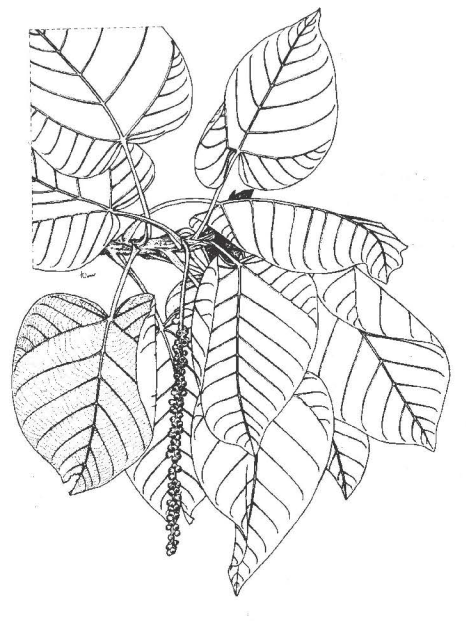

**Figure 7.2:** *Octomeles sumatrana*.

| **PWOc** |  | *kuRim(a,o), *iRim(a,o) | ‘*Octomeles sumatrana*’ (ACD: *iRimo) |
| --- | --- | --- | --- |
| NNG | Mangap | *kurīmi* | ‘*Octomeles sumatrana*’ |
| NNG | Yabem | *(ka)kelim* | ‘tree with large leaves and thick, strong trunk’ (identified as *Octomeles* sp. by Lane-Poole 1925) |
| PT | Motu | *irimo* | ‘tree sp. from which canoes are generally made’ |
| PT | Ubir | *irim* | ‘tree sp., used for canoes’ |
| PT | Tawala | *ilimo* | ‘large tree sp., used for war canoes’ |
| MM | Nakanai | *(ko)imu* | ‘*Octomeles sumatrana*’ (zero for †*-l-* < *-R-) |
| MM | East Kara | *ima* | ‘*Octomeles sumatrana*’ |
| MM | Madak | *ima* | ‘tree sp.’ |
| MM | Patpatar | *irime* | ‘*Octomeles sumatrana*’ |
| MM | Tolai | *irima* | ‘*Octomeles sumatrana*’ |
| MM | Label | *irimu* | ‘*Octomeles sumatrana*’ |
| MM | Teop | *inimo* | ‘*Octomeles sumatrana*’ (Record 1945) |
| MM | Babatana | *vurima* | ‘*Octomeles sumatrana*’ (McClatchey et al. 2005) |

## 4. The forest canopy

As a rough rule of thumb, trees of the forest canopy are assumed to be those which grow to between 30 and 50 m. There are also several species, noted in the subsections of §5, which are usually sub-canopy trees but which grow taller in some localities and become part of the canopy itself.

Certain trees of the forest canopy are treated elsewhere in this volume. Strangler figs become part of the forest canopy by using an existing tree as host to piggyback their way into the light (ch.1 0, §4). *Canarium* species and *Terminalia* species, especially *Terminalia kaernbachii*, and *Pometia pinnata*, are canopy trees in the Bismarcks, but have also long been cultivated, the first two for their nuts and *Pometia pinnata* for its fruit, and are thus treated in ch.11 (§§2.1, 2.4 and 3.5 respectively).

### 4.1. *Campnosperma brevipetiolatum* (Anacardiaceae)

*Campnosperma brevipetiolatum* is a large canopy tree, growing up to 50 m in height. Its straight smooth trunk has a cylindrical bole, usually up to 1.2 min diameter and occasionally as much as 2m (Conn & Damas 2006).

The Bola of New Britain use it for canoe hulls (Powell 1976). The Marovo consider it inferior to *Gmelina moluccana* for this purpose, but good for house planks (Hviding 2005: 134).

*Campnosperma brevipetiolatum* is apparently not found in Remote Oceania, and its distribution in the Bismarcks and the Solomons seems to be patchy, as it is missing from the usually very thorough Peekel (1984) and Henderson & Hancock (1988). There is just one weakly supported POc term for the species, namely *olaŋa.

| **POc** |  | *olaŋa | ‘*Campnosperma brevipetiolatum*’ |
| --- | --- | --- | --- |
| Adm | Bipi | *laŋ* | ‘*Campnosperma brevipetiolatum*’ (O’Collins and Lamothe 1989) |
| Adm | Nyindrou | *lam* | ‘*Campnosperma brevipetiolatum*’ (O’Collins and Lamothe 1989) |
| MM | Marovo | *olaŋa* | ‘*Campnosperma brevipetiolatum*’ |

### 4.2. *Cinnamomum* spp., wild cinnamon (Lauraceae)

Trees of the genus *Cinnamomum* grow to 30 m. They are known for their barks, which are widely processed to make spices and to extract essential oils. Only one of the items in the cognate set supporting POc *(m,mʷ)aso(q)u ‘*Cinnamomum* sp.’ includes a species-level identification within the genus *Cinnamomum*: Lou *moso* is glossed as *Cinnamomum xanthoneuron*, a ‘wild cinnamon’. This is not one of the three species that provide commercial cinnamon bark,[^6]: but one of two tree species exploited by German traders on the north coast of New Guinea under German colonial rule and into the 1930s for their essential oils. The other was not a *Cinnamomum* species but *Cryptocarya aromatica* (syn. *Cryptocarya massoy*, *Massoia aromatica*), and there was much confusion as to which oil came from the bark of which tree. The oils from these two species are known as lawag oil and massoia oil.[^7]: It is possible that Mager’s gloss of the Bing and Gedaged reflexes as *Cryptocarya aromatica* reflects this confusion and that the intended denotatum was *Cinnamomum xanthoneuron*. At any rate, it seems likely that POc *(m,mʷ)aso(q)u did indeed denote *Cinnamomum xanthoneuron*. The fragrance of *Cinnamomum xanthoneuron* (and/or *Cryptocarya aromatica*) bark was known to the traditional residents of north New Guinea and the Bismarcks, as Mager (19 52: 204) reports in his gloss of the Gedaged and Bing items,

> The bark is used a great deal in sorcery. It is chewed and spit [sic] out into the face of the spirits, so as to drive them away. A piece of bark is carried in the net bag to keep evil spirits from harming the child.

Arentz et al. (1989: 92) also report that on New Britain the bark is consumed as a medicine against fever and stomach pain.

POc *(m,mʷ)aso(q)u has cognates in the languages of Java: Sundanese *maŋsoi*, Javanese *masoyi*, *masogi*, Madurese *masoji*, all denoting massoia oil rather than a tree species. The species label ‘massoy’ and the term ‘massoia’ are probably derived from the Javanese term, but, as a result of the confusion between the two oils, are applied to *Cryptocarya aromatica*, syn. massoy, and its essential oil, rather than to *Cinnamomum xanthoneuron*. It seems likely, incidentally, that Are *masoɣi* (for †*masou*) is a borrowing, perhaps indirectly, from Javanese, rather than a directly inherited reflex of *(m,mʷ)aso(q)u.[^8]:

The reflexes of POc *(m,mʷ)aso(q)u reveal a further set of complications. (Blust 1981a) glosses the Lou and Nauna terms ‘*Cananga odorata*’ (§5.2), rather than a *Cinnamomum* species, and this is also the gloss of the Meso-Melanesian reflexes. Fijian has two terms: Bauan *maðou* ‘wild cinnamon, *Cinnamomum* sp.’ and Bauan *makosoi* / Wayan *mākosoi*, both ‘*Cananga odorata*’. The latter appear to be metathesised forms of a PCP compound *(m,mʷ)aso-koi ‘perfume tree, *Cananga odorata*’.[^9]: This raises the possibility that POc *(m,mʷ)aso(q)u denoted *Cananga odorata* as well as cinnamon, i.e. that it denoted a taxon of perfumed trees. PCP then seems to have distinguished between *(m,mʷ)aso ‘cinnamon’ and *(m,mʷ)aso-koi ‘*Cananga odorata*’.

The possibility that there was such a taxon is strengthened by an observation by Will McClatchey (pers. comm.) that the quote from Mager above could also be applied to the Fijian and Western Polynesian use of *Cananga odorata*.

The Meso-Melanesian forms below, apparently reflecting PMM *mud(e)u (rather than †*moso(u)) are problematic. They may reflect a PMM borrowing or a non-cognate chance resemblance.

| **POc** |  | *(m,mʷ)aso(q)u | ‘wild cinnamon, *Cinnamomum* sp., probably *Cinnamomum xanthoneuron*; possibly also *Cananga odorata*’ (Milke 1968) |
| --- | --- | --- | --- |
| Adm | Mussau | *mosou* | ‘wild cinnamon, *Cinnamomum* sp.’ |
| Adm | Lou | *moso* | ‘tree with redolent bark, the cinnamon, *Cinnamomum xanthoneuron*’ |
| Adm | Baluan | *mʷasow* | ‘wild cinnamon, *Cinnamomum* sp.’ |
| Adm | Nauna | *moso* | ‘*Cananga odorata*’ (Blust 1981a) |
| NNG | Mengen | *miau* | ‘*Cinnamomum* sp.’ |
| NNG | Kove | *modou* | ‘aromatic plant, possibly cinnamon, used in healing’ (A. Chowning, pers. comm.) |
| NNG | Yabem | *mʋsı* | ‘wild cinnamon, *Cinnamomum* sp.’ |
| NNG | Bing | *miyou* | ‘*Cryptocarya aromatica*’ (Mager 1952: 204) |
| NNG | Gedaged | *mio* | ‘*Cryptocarya aromatica*’ (Mager 1952: 204) |
| NNG | Megiar | *muyou* | ‘cinnamon bark’ (Kasprus 1945) |
| PT | Are | *masoɣi* | ‘wild cinnamon, *Cinnamomum* sp.’ (borrowed ?) |
| MM | East Kara | *mədeu* | ‘*Cananga odorata*’ |
| MM | Nehan | *mudu-mud* | ‘*Cananga odorata*’ |
| MM | Varisi | *mudu-mudu* | ‘*Cananga odorata*’ (McClatchey et al. 2005) |
| MM | Ririo | *mud-mud* | ‘*Cananga odorata*’ (W. McClatchey, pers. comm.) |
| MM | Babatana | *mudu-mudu* | ‘*Cananga odorata*’ (McClatchey et al. 2005) |
| MM | Nduke | *mu-mudu* | ‘*Cananga odorata*’ |
| MM | Marovo | *mudu* | ‘a tree of the secondary forest, with yellow fragrant flowers that are used in coconut oil’ |
| Fij | Bauan | *maðou* | ‘wild cinnamon, *Cinnamomum* sp.’ |
| **PCP** |  | *(m,mʷ)aso-koi | ‘perfume tree, *Cananga odorata*’ (Milke 1961) |
| Fij | Wayan | *mākosoi* | ‘*Cananga odorata*’ (metathesis) |
| Fij | Bauan | *makosoi* | ‘*Cananga odorata*’ (metathesis) |
| **PPn** |  | *mosokoi | ‘*Cananga odorata*’ |
| Pn | Tongan | *mohokoi* | ‘*Cananga odorata*’ |
| Pn | East Futunan | *mosokoi* | ‘*Cananga odorata*’ |
| Pn | Tikopia | *mosokoi* | ‘*Cananga odorata*’ |
| Pn | Samoan | *mosoʔoi* | ‘*Cananga odorata*’ |

cf. also:

| SES | Kwara’ae | *mudu* | ‘*Dillenia ingens*’ |
| --- | --- | --- | --- |
| Fij | Rotuman | *moskoy* | ‘tree with greenish-yellow flowers and clusters of fruit; timber used for canoes’ (Polynesian borrowing) |

### 4.3. *Dillenia schlechteri* (syn. *Dillenia macrophylla*) (Dilleniaceae)

There are many *Dillenia* species in SE Asia and Oceania, some of them tall canopy trees, others smaller trees of the lower canopy.[^10]: Only one species is reported from the Bismarcks (Peekel 1984: 375, Conn & Damas 2006), *Dillenia schlechteri*, a canopy tree 30–50 m tall with a light red trunk. However, there is linguistic evidence in the form of POc *drokol (§5.4) that at least one sub-canopy species was known to POc speakers.

In the Admiralties *Dillenia schlechteri* is used for house construction. The timber is said to last over 30 years if it is not exposed to the elements (O’Collins & Lamothe 1989).

The second and third vowels and the possible final consonant of POc *kulapu(R) ‘*Dillenia* schlechteri’ are due to the reconstruction of PMP *kelabuR ‘large *Dillenia* species’ on the basis of the data below and of Blit Manobo *klambug (daka)* ‘*Dillenia megalantha*’ (cf§5.4), Bagobo *kalambok*, Lanao *kalambuguy*,[^11]: both ‘*Dillenia philippinensis*’ (Madulid 2001b: 100).

| **PMP** |  | *kelabuR | ‘large *Dillenia* species’ |
| --- | --- | --- | --- |
| **POc** |  | *kulapu(R) | ‘*Dillenia schlechteri*’ |
| Adm | Nyindrou | *kun* | ‘*Dillenia* sp.’ |
| MM | Patpatar | *(e)kulap* | ‘*Dillenia schlechteri*’ |
| Fij | Bauan | *kuluva* | ‘*Dillenia biflora*’ (Keppel et al. 2005) |
| Fij | Wayan | *kulu-kulu* | ‘*Dillenia biflora*’[^12] |

### 4.4. *Dracontomelon dao* (syn. *Dracontomelon mangiferum*, *Dracontomelon edule*), New Guinea walnut, Dragon plum, TP *mon*, B *nakatambol* (Anacardiaceae)

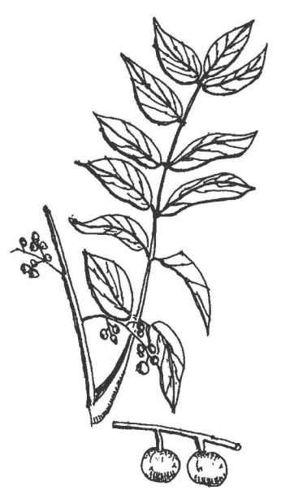

**Figure 7.3:** *Dracontomelon dao*, New Guinea Walnut.

The New Guinea walnut tree, *Dracontomelon dao*, is massive, usually reaching 30-35 m, and occasionally 50 m, in height. It has large buttresses and above the buttresses often has a circumference of 3-5 m. At a height of about 7-10 m the trunk divides into a pair of large branches. Each of them continues to divide upwards and sideways recursively to form a large umbrella-shaped crown. The leaves are made up of 6 to 10 leaflets with a smooth edge (Figure 7.3). The fruit are small, 2-3 cm in diameter, and have five flecks around them. The small amount of flesh around the flattened seed is edible but tart and is consumed fresh (Peekel 1984: 323, French 1986: 238). *Dracontomelon dao* occurs from SE Asia to the Solomons (Walter & Sam 2002: 158).

Bourke (in preparation, n.d.) writes that although *Dracontomelon dao* was traditionally a significant fruit in the area around Madang, it is unimportant or absent elsewhere in the lowlands of New Guinea. Places where it is recorded as being eaten are the Schouten Islands off the mouth of the Sepik River, some of the small islands in the Admiralties, some islands in SE Papua, the Duke of York Islands (between New Britain and New Ireland), Nissan Island (between New Ireland and Bougainville) and Bougainville. The only report of cultivation comes from French, who says it is sometimes planted from seed.

Two terms are reconstructable: POc *raqu(p) and PNCV *katabola. The final bracketed *-p of *raqu(p) is added to take account of th1e final consonants of the Patpatar and Tolai reflexes. However, there are no known non-Oceanic reflexes of *-p. The PCP *tawa-raqu ‘*Dracontomelon vitiense*’ contains a reflex of POc *tawan ‘*Pometia pinnata*’ (ch. 11, §3.5) as its first element, as the fruits of the two plants are similar in appearance (Geraghty 2004: 80).

| **PAn** |  | *daqu | ‘*Dracontomelon dao*’ (Blust 1986) |
| --- | --- | --- | --- |
| **POc** |  | *raqu(p) | ‘New Guinea walnut, *Dracontomelon dao*’ |
| Adm | Mussau | *ra* | ‘*Dracontomelon dao*’ |
| Adm | Nyindrou | *ⁿrau* | ‘*Dracontomelon* sp.’ |
| Adm | Baluan | *you* | ‘*Dracontomelon dao*’ |
| NNG | Lukep | *rak* | ‘*Dracontomelon dao*’ |
| NNG | Takia | *rau* | ‘*Dracontomelon dao*’ |
| MM | Nakanai | *lahu* | ‘a tall tree (Anacardiaceae) used for planks’ |
| MM | Tolai | *laup* | ‘*Dracontomelon dao*’ (for †*rau*) |
| MM | Patpatar | *loh* | ‘*Dracontomelon dao*’ (for †*ro*) |
| **PROc** |  | *raqu | ‘dragon plum tree, *Dracontomelon dao*’ |
| NCV | Mwotlap | *ye* | ‘*Dracontomelon dao*’ |
| NCV | Mota | *rau* | ‘a fruit tree’ |
| NCV | Paamese | *e-au* | ‘*Dracontomelon dao*’ |
| NCV | Lewo | *(puru-)lu* | ‘*Dracontomelon dao*’ |
| NCV | Namakir | *raʔ* | ‘*Dracontomelon dao*’ |
| NCV | Nguna | *na-rau* | ‘*Dracontomelon dao*’ |
| NCV | Nguna | *na-rau* | ‘*Dracontomelon dao*’ |
| SV | Sye | *na-raɣ* | ‘*Dracontomelon dao*’ |
| SV | Kwamera | *nə-rai* | ‘*Dracontomelon dao*’ |
| **PCP** |  | *(tawa)raqu | ‘dragon plum tree, *Dracontomelon vitiense*’ |
| Fij | Wayan | *(tawa)rau* | ‘*Dracontomelon vitiense*’ |
| Fij | Rotuman | *(jav)rau* | ‘*Dracontomelon vitiense*’ (Geraghty 2004: 80) |
| Pn | Emae | *(tava)rau* | ‘*Dracontomelon vitiense*’ (Geraghty 2004: 80) |
| Pn | West Futunan | *(tave)rau* | ‘*Dracontomelon vitiense*’ (Geraghty 2004: 80) |

| **PNCV** |  | *katabola | ‘*Dracontomelon dao*’ (Clark 1996) |
| --- | --- | --- | --- |
| NCV | Ambae | *gatabola* | ‘*Dracontomelon dao*’ |
| NCV | Kiai | *atapolo* | ‘*Dracontomelon dao*’ |
| NCV | Raga | *ɣatabola* | ‘tree sp.’ (Walsh 2004) |
| NCV | Tamambo | *(vu)hatabola* | ‘tree sp.’ |
| NCV | Big Nambas | *na-hatapul* | ‘*Dracontomelon dao*’ |
| NCV | Uripiv | *ni-tapol* | ‘*Dracontomelon dao*’ |
| NCV | Naman | *n-atabal* | ‘*Dracontomelon dao*’ |
| NCV | Neve’ei | *na-ʔatebʷel* | ‘*Dracontomelon dao*’ |
| NCV | Avava | *atibol* | ‘*Dracontomelon dao*’ |
| NCV | Nese | *ɣatabol* | ‘*Dracontomelon dao*’ |

### 4.5. *Dysoxylum* spp., stinktree, stinkwood, B *stingwud* (Meliaceae)

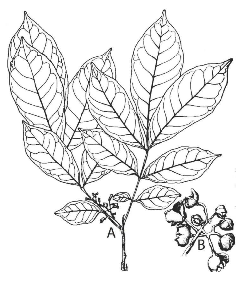

**Figure 7.4:** *Dysoxylum arborescens*.

A number of *Dysoxylum* species grow in NW Island Melanesia, ranging from the tall canopy tree *Dysoxylum gaudichaudianum* (syn. *D. amooriodes*) sometimes growing to 35 m, to the sub-canopy tree *Dysoxylum kaniense*. An important tree between these extremes is *Dysoxylum arborescens*, also a canopy tree, but usually only 20–30 m high (Wheatley 1992: 157-160, Kwa’ioloa & Burt2001: 181, Conn & Damas 2006).

A salient feature of all *Dysoxylum* species is their strong smell, which varies from species to species: some are unpleasant, some pleasant (W. McClatchey, pers. comm.). The unpleasant smell of certain *Dysoxylum* species has earned them the English name ‘stinktree’ or ‘stinkwood’: when the bark is stripped off and fresh wood is exposed, *Dysoxylum gaudichaudianum* is said by the Kwara’ae to smell like a man who has not washed and *Dysoxylum kaniense* to have a smell that induces vomiting (Kwa’ioloa & Burt 2001: 122, 181). Whistler (1991b: 93) comments that the leaves have ‘a disagreeable odor’. Despite the smell, the wood of *Dysoxylum* species is a useful hardwood, and the timber of the larger species is widely used for house posts (Floyd 1954, Whistler 1991b: 93, Wheatley 1992: 157, 162, Kwa’ioloa & Burt 2001: 122).

POc *maqota perhaps denoted a taxon including several *Dysoxylum* species. All the species mentioned in the glosses below are tall canopy trees except *Dysoxylum kaniense* and *Dysoxylum spectabile*, but this is perhaps because the larger species are more widespread and more salient.

Lynch (2001c: 242) attributes the SV members of the two cognate sets below to a single PSV etymon *ni-m(d,t)awan, but they appear to reflect two etyma. PSV *nə-mtaw reflects metathesis of a variant form *mawota, also reflected in Bauan Fijian *mavota*. Proto Erakor-Tafea (Lynch 2001c: 189) *tuan is a separate etymon.[^13]:

| **POc** |  | *maqota | ‘*Dysoxylum* spp.’ |
| --- | --- | --- | --- |
| PT | Muyuw | *(a)mʷakot* | ‘a 20-metre *Dysoxylum* sp.’ |
| SES | Kwara’ae | *maoa* | ‘*Dysoxylum kaniense*’ |
| NCV | Mwotlap | *ma-mot* | ‘*Dysoxylum arborescens*’ |
| NCV | Mota | *ma-maota* | ‘tree sp.’ |
| **PSV** |  | *na-mtaw | ‘*Dysoxylum* sp.’ (Lynch 2001c) |
| SV | Sye | *ni-mtu* | ‘*Dysoxylum aneityense*’ |
| SV | Anejom̃ | *ne-mtav* | ‘*Dysoxylum aneityense*’ |
| Fij | Bauan | *mavota* | ‘*Myristica grandiflora*’ (for †*maota*) |
| Pn | Tongan | *moʔota* | ‘taxon of three *Dysoxylum* spp., but primarily *Dysoxylum forsteri*’ (’Whistler 1991b: 92-93) |
| Pn | Niuean | *moota* | ‘tree, *Dysoxylum richii*, timber used to build main hull of canoe’ (also *maota*) |
| Pn | East Uvean | *maʔota* | ‘*Dysoxylum samoensis*’ |
| Pn | East Futunan | *māʔota* | ‘shrub sp., *Dysoxylum forsteri*’ |
| Pn | Rennellese | *maʔota* | ‘tree sp., *Dysoxylum gaudichaudianum*, valuable for house timbers’ |
| Pn | Samoan | *maota* | ‘*Dysoxylum* spp.’ (Whistler 2000: 181) |
| Pn | Takuu | *maota* | ‘hard, red, wood that drifts to Takuu’ |
| Pn | Māori | *māota* | ‘*Dysoxylum spectabile*’ |

| **Proto Erakor-Tafea** |  | *tuan | ‘*Dysoxylum* spp.’ |
| --- | --- | --- | --- |
| NCV | South Efate | *ne-tue* | ‘*Anthocarapa nitidula*’ (Wheatley 1992: 157) |
| SV | Lenakel | *ne-tuan* | ‘*Dysoxylum gaudichaudianum*’ |
| SV | Kwamera | *nə-tuan* | ‘*Dysoxylum gaudichaudianum*’ |

### 4.6. *Elaeocarpus* spp. (Elaeocarpaceae)

*Elaeocarpus* species in NW Island Melanesia include the large canopy trees *Elaeocarpus angustifolius* (syn. *Elaeocarpus sphaericus*) with its distinctively cornflower-blue fruit and *Elaeocarpus floridanus*, more common in the Solomons than the Bismarcks, with dark blue or black fruit (syn. *Elaeocarpus pseudosepicanus*), both 25 or more metres tall, as well as shrub-sized trees of the understorey like *Elaeocarpus edulis* (syn. *Aceratium oppositifolium*), 3-6 m tall, with its 4 x 3cm ellipsoid apple-red fruit. The fruits of all species are inedible (Peekel 1984: 352-353, Wheatley 1992: 85, Kwa’ioloa & Burt 2001: 123).

The large species provide wood for house beams at various locations (Record 1945, Arentz et al. 1989: 94), but Will McClatchey (pers. comm.) finds that it is not useful in the traditional communities which he has studied.

Two reconstructions are presented below. PEOc *melo ‘*Elaeocarpus angustifolius*’ is supported by just two reflexes, but the languages are sufficiently far apart to preclude borrowing.

| **PEOc** |  | *melo | ‘*Elaeocarpus angustifolius*’ |
| --- | --- | --- | --- |
| SES | Kwara’ae | *melo* | ‘*Elaeocarpus angustifolius*’ |
| NCV | Vera’a | *mel* | ‘*Elaeocarpus angustifolius*’ |

| **PSV** |  | *na-(s,j)u(v,w)as | ‘*Elaeocarpus angustifolius*’ (Lynch 2004a) |
| --- | --- | --- | --- |
| SV | Sye | *ne-yoh* | ‘*Elaeocarpus angustifolius*’ |
| SV | Kwamera | *nə-suvas* | ‘k.o. tree with edible seeds in a hairy pod’ |
| SV | Anejom̃ | *na-woθ* | ‘*Elaeocarpus angustifolius*’ |

### 4.7. *Endospermum* spp., cheesewood, milkwood, whitewood, PNG basswood, B *waetwud*, *melektri* (Euphorbiaceae)

Within island Melanesia *Endospermum medullosum* (Figure 7.5, left) is present in the Bismarcks, the Solomons and Vanuatu; *Endospermum moluccanum* is reported only from the Bismarcks (Peekel 1984: 313, Wheatley 1992:91, Hviding 2005: 135). Occasionally an emergent tree, otherwise a large canopy tree up to 45 m high, *Endospermum medullosum* has a markedly fluted bole of 45-100 cm diameter, sometimes crooked, sometimes straight and up to 25 m long. It has a distinctive crown, shallow, flat-topped and umbrella-like. Its distribution is limited by the fact that it does not tolerate shade: it grows well only where there are gaps in the canopy (Thomson 2006a).

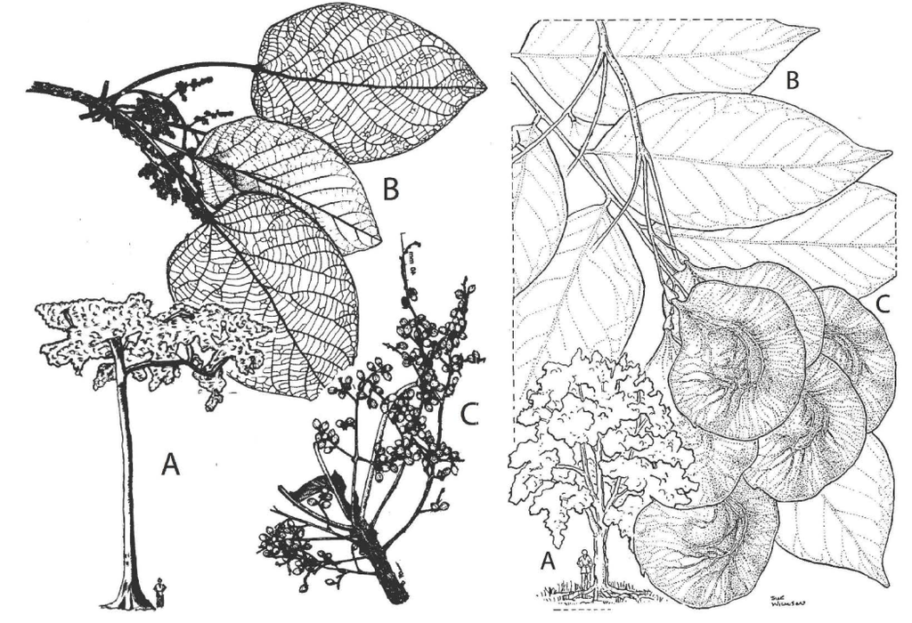

**Figure 7.5:** **Left** *Endospermum medullosum*, cheesewood,: **A**, tree; **B**, leaves and flowers; **C**, fruit. **Right** *Pterocarpus indicus*, New Guinea rosewood: **A**, tree; **B**, portion ofleafwith leaflets; **C**, shoot with pods.

A somewhat smaller but similar member of the genus is *Endospermum moluccanum* (syn. *Endospermum formicarum*),[^14]: sometimes a canopy tree up to 25m high, sometimes a sub-canopy tree (Conn & Damas 2006).

Both species have lightweight wood that is used for fishing-net floats. Peekel (1984: 315) reports from New Ireland that the pith of the twigs of *Endospermum moluccanum* is usually destroyed by black ants, which inhabit the resulting space. Kwa’ioloa & Burt (2001: 115) report from Kwara’ae that *Endospermum medullosum* is not used in house construction because the wood is eaten by insects.

POc *koma(r,R)(o,u) may have referred to either or both species. Like the large *Elaeocarpus* species (§4.6), *Endospermum* species are not prominent in Bismarcks rain forests, and appear to have undergone a good deal of local re-naming.

| **POc** |  | *koma(r,R)(o,u) | ‘*Endospermum* sp.’ |
| --- | --- | --- | --- |
| MM | Nakanai | *ko-komalu* | ‘*Endospermum moluccanum*’ |
| NCV | Mwotlap | *no-komʷa* | ‘*Endospermum* sp.’ |
| NCV | Araki | *(vi)kunᫀaro* | ‘*Endospermum medullosum*’ |
| NCV | Tangoa | *(vi)kumaro* | ‘*Endospermum medullosum*’ (Gowers 1976: 73) |
| NCV | Sakao | *(du)gomara* | ‘*Endospermum medullosum*’ (Gowers 1976: 73) |

### 4.8. *Garuga floribunda* (syn. *Garuga abilo*), B *namalaus* (Burseraceae)

*Garuga floribunda* is a canopy tree which grows to a height of up to 25m in Vanuatu and up to 35m in Papua New Guinea (Wheatley 1992:63, Conn & Damas 2006). It has a short bole and steeply rising branches, often with a flat crown (Johns 1976: 195). According to Paijmans (1976: 52) its occurrence is limited to the few locations where there is a marked dry season.

There is apparently a traditional perception that *Garuga floribunda* resembles the smaller *Spondias cytherea*, noted by Peekel (1984: 283) for New Ireland and reflected in PNCV *mala-usi ‘*Garuga floribunda*’, reconstructed below. The perception is apparently based on the fact that both trees lose their leaves and are bare between flowering and fruiting. PNCV *mala-usi consists of a reflex of the POc prefix *mala- ‘resembling’ (ch.2, §7.1.4) plus PNCV *usi ‘*Spondias cytherea*’ (ch.ll, §3.6), i.e. its original meaning was evidently ‘resembing *Spondias cytherea*’. As noted below, there are also unprefixed reflexes of PNCV *usi which denote *Garuga floribunda*.

PCP *manaui ‘*Garuga floribunda*’, also below, appears cognate with the PNCV form, but the medial consonants do not correspond, suggesting that one of the two forms is the result of borrowing. Since PNCV *mala- regularly reflects POc *mala-, but PCP *mana- (instead of expected †*mala-) does not, it is the Central Pacific forms that appear to reflect a borrowing.

| **PNCV** |  | *malausi | ‘*Garuga floribunda*’ (from data in Wheatley 1992) |
| --- | --- | --- | --- |
| NCV | Mota | *mʷa-mʷalau* | ‘*Garuga floribunda*’ |
| NCV | Ambae | *malawhi* | ‘*Garuga floribunda*’ |
| NCV | Nduindui | *malaouk* | ‘*Garuga floribunda*’ |
| NCV | Tamambo | *(vu)malaus* | ‘*Garuga floribunda*’ |
| NCV | Tangoa | *(vi)malaus* | ‘*Garuga floribunda*’ |
| NCV | Tolomako | *na-malaus* | ‘*Garuga floribunda*’ |
| **PCP** |  | *manaui | ‘*Garuga floribunda*’ |
| Fij | Wayan | *manawī* | ‘a tree of dry forest, *Rhus taitensis*’[^15] |
| Pn | Tongan | *manaui* | ‘*Garuga floribunda*’ |
| Pn | East Futunan | *manaui* | ‘large forest tree, *Myristica* hypargyraea’ |
| Pn | Samoan | *maŋaui* | ‘a large tree, *Garuga floribunda*’ (Whistler 2000: 179) |

| **PNCV** |  | *usi | ‘mummy apple, *Spondias cytherea*’ (from data in Wheatley 1992) |
| --- | --- | --- | --- |
| NCV | Maewo | *o-us* | ‘*Garuga floribunda*’ |
| NCV | Nduindui | *uhi* | ‘*Garuga floribunda*’ |
| NCV | Tolomako | *na-us* | ‘*Garuga floribunda*’ |
| NCV | Tangoa | *(vi)usi* | ‘*Garuga floribunda*’ |
| NCV | Uripiv | *na-us* | ‘*Garuga floribunda*’ |

### 4.9. *Intsia bijuga* (syn. *Intsia amboinensis*, *Afzelia bijuga*), ironwood, island teak, TP *kwila*, B *natora* (Cisalpiniaceae)

One of the larger trees of the forests of NW Island Melanesia, *Intsia bijuga* grows 40-45 m tall and sometimes more (Figure 7.6, left). It is common on the foreshore, but also occurs in lowland rain forests (Peekel 1984: 214-216).

*Intsia bijuga* is considered one of the strongest and most durable woods in NW Island Melanesia and Vanuatu. It seasons slowly with very little shrinkage and is durable in the ground, resistant to termites and moderately durable in salt water (Gowers 1976: 91). Its uses range from house posts and floorboards to axe handles, slitgongs and wooden bowls (Streicher 1982, Arentz et al. 1989:94, Whistler 1991b: 125, Hviding 2005: 122, F. Damon, pers. comm.). Damon reports that on Woodlark Island it was used for the steering oars of the large canoes that plied the eastern half of the Kula ring.

Superficially, it looks as if there were two POc terms for *Intsia bijuga*: *toRas and *qipil. However, Blust’s gloss of PMP *teRas as ‘hard, hardwood’ suggests that POc *toRas too may have denoted ‘hardwood’ in general or a taxon of hardwood trees, rather than *Intsia bijuga* in particular. This would explain why some of its reflexes denote other hardwood trees. In particular, its Proto Polynesian reflex, *toa, was reapplied to *Casuarina equisetifolia*. In Muyuw the term *meikʷ* is used both for *Intsia bijuga* and for the hard heartwood of any tree (F. Damon, pers. comm.). Thus one word for hardwood has been replaced by another in naming *Intsia bijuga*.

It seems that PMP *teRas / POc *toRas was, in one of its senses, a stative verb meaning ‘hard, durable’. PMic had a stative verb *ma-toa ‘be firm, hard strong’ (Bender et al. 2003: 54), and tree-denoting reflexes sometimes occur with verbal morphology. In CMP languages we find W Sumba, E Sumba *kandora*, E Sumba *mandora* ‘*Calophyllum inophyllum*’ (Verheijen 1990: 197), reflecting the PMP stative prefixes *ka- and *ma- respectively (Evans & Ross 2001).

Polynesian languages, meanwhile, have reapplied the PCP reflex of POc *pesi ‘a coastal forest tree, perhaps *Pongamia pinnata*’ to *Intsia bijuga* (ch.5, §5.12).

| **PMP** |  | *teRas | ‘hard; hardwood’ (Blust 1972a) |
| --- | --- | --- | --- |
| **POc** |  | *toRas | ‘a taxon of hardwood trees including *Intsia bijuga*’ (?) |
| Adm | Seimat | *tor* | ‘*Intsia bijuga*’ (*-r* for †*-ŋ*: borrowed?) (Sorensen 1950) |
| Adm | Lou | *to* | ‘*Intsia bijuga*’ |
| NNG | Kairiru | *tor* | ‘*Intsia bijuga*’ |
| MM | Sursurunga | *toraha* | ‘a hardwood tree’ |
| MM | Nehan | *toraha* | ‘tree sp. with strong yellowish-white wood, used for carving slitgong drums and paddles’ |
| MM | Halia | *tolasa* | ‘same tree: sp. as Nehan *toraha*’ |
| MM | Petats | *tolas* | ‘*Vitex monophylla*’ |
| MM | Teop | *tora* | ‘*Vitex monophylla*’ |
| MM | Maringe | *tʰola* | ‘type of large softwood tree; canoe with two upraised ends’ |
| **PEOc** |  | *toRa(s) | ‘a hardwood tree, *Intsia bijuga*’ |
| SES | Lau | *ola* | ‘a canoe built of planks sewn together’ |
| SES | Kwara’ae | *uʔula* | ‘*Intsia bijuga*’ (*o > *u*: irregular change) |
| SES | Arosi | *ora* | ‘tree sp. from which best canoes are made; plank-built canoe’ |
| NCV | Mwotlap | *no-toy* | ‘*Decaspermum neoebudicum*’ |
| NCV | Merlav | *tor* | ‘*Casuarina equisetifolia*’ (François 2004b) |
| NCV | South Efate | *na-tor* | ‘*Intsia bijuga*’ |
| NCV | Mota | *tora* | ‘a timber tree’ |
| NCV | Ambae | *tora* | ‘*Intsia bijuga*’ |
| NCV | Tamambo | *(vu)tora* | ‘*Intsia bijuga*’ |
| NCV | Raga | *tora* | ‘*Intsia bijuga*’ |
| NCV | Atchin | *tor* | ‘tree sp., used for canoes, posts, etc.’ |
| NCV | Nese | *na-toɾ* | ‘*Intsia bijuga*’ |
| NCV | Uripiv | *na-toɾ* | ‘*Intsia bijuga*’ |
| NCV | Paamese | *a-to* | ‘tree sp. with sap which stings’ |
| Fij | Bauan | *doa* | ‘the heartwood of a tree, solid and dark’ |
| **PPn** |  | *toa | ‘*Casuarina equisetifolia*’ (POLLEX) |
| Pn | Niuean | *toa* | ‘*Casuarina equisetifolia*’ |
| Pn | Tongan | *toa* | ‘*Casuarina equisetifolia*’ |
| Pn | East Uvean | *toa* | ‘*Casuarina equisetifolia*’ |
| Pn | East Futunan | *toa* | ‘*Casuarina equisetifolia*’ |
| Pn | Rennellese | *toa* | ‘*Casuarina equisetifolia*’ |
| Pn | Emae | *toa* | ‘*Casuarina equisetifolia*’ |
| Pn | Tikopia | *toa* | ‘*Casuarina equisetifolia*’ |
| Pn | West Futunan | *toa* | ‘*Casuarina equisetifolia*’ |
| Pn | Ifira-Mele | *toa* | ‘*Casuarina equisetifolia*’ |
| Pn | Samoan | *toa* | ‘*Casuarina equisetifolia*’ |
| Pn | Tahitian | *toa* | ‘*Casuarina equisetifolia*’ |
| Pn | Tuamotuan | *toa* | ‘*Casuarina equisetifolia*’ |
| Pn | Marquesan | *toa* | ‘*Casuarina equisetifolia*’ |
| Pn | Māori | *toa-toa* | ‘Phyllocladus glaucus’ |

The inherited meaning of POc *qipil was apparently ‘*Intsia bijuga*’, but the glosses of its reflexes suggest that it also denoted ‘*Casuarina equisetifolia*’. Note that ‘ironwood’ and ‘*kwila*’ both refer to ‘*Intsia bijuga*’.

| **PMP** |  | *qipil | ‘a hardwood tree, *Intsia bijuga*’ (ACD; Dempwolff 1938: *ipil) |
| --- | --- | --- | --- |
| **POc** |  | *qipil | ‘a taxon of hardwood trees including *Intsia bijuga* and *Casuarina equisetifolia*’ (ACD: *(q)ipil) |
| Adm | Drehet | *ʔih* | ‘ironwood’ |
| Adm | Likum | *ih* | ‘*Casuarina equisetifolia*’ |
| Adm | Nyindrou | *eih* | ‘ironwood’ |
| MM | Tolai | *ip* | ‘tree sp.’ |
| MM | Teop | *ivin* | ‘a hardwood tree, *kwila*’ |
| MM | Mono-Alu | *ihili* | ‘*Intsia bijuga*’ (W. McClatchey, pers. comm.) |
| MM | Ririo | *kivil* | ‘*Intsia bijuga*’ |
| MM | Babatana | *kivili* | ‘*Casuarina equisetifolia*’ |
| MM | Marovo | *kivili* | ‘*Casuarina equisetifolia*’ |
| MM | Roviana | *kifli* | ‘*Intsia bijuga*’ (W. McClatchey, pers. comm.) |
| MM | Kia | *ivili* | ‘*Intsia bijuga*’ |
| MM | Maringe | *khifli* | ‘*Intsia bijuga*’ (W. McClatchey, pers. comm.) |
| NCV | Mwotlap | *n-ip* | ‘*Casuarina equisetifolia*’ |
| Mic | Kiribati | *ibi* | ‘tree like *Calophyllum inophyllum*, but harder and heavier’ |
| Pn | Samoan | *ifi(fatu)* | ‘*Intsia bijuga*’ |
| Pn | Samoan | *ifi(lele)* | ‘a hard-grained *Intsia bijuga*’ |

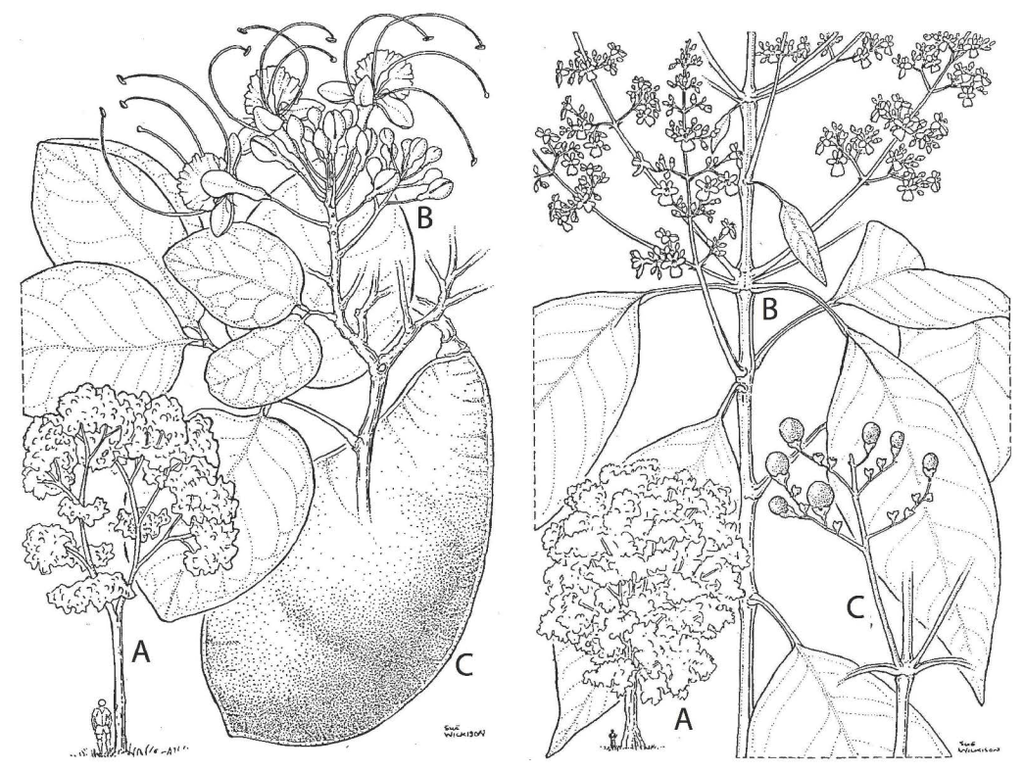

**Figure 7.6:** **Left** *Intsia bijuga*, ironwood: **A**: young tree; **B**, leaves and flowers; **C**, seed pod. Right *Vitex cofassus*, New Guinea teak: **A**, tree; **B**, flowering stem with leaves and portion of terminal inflorescence; **C**, portion of fruiting inflorescence and stem.

| **PWOc** |  | *bʷana | ‘*Intsia bijuga*’ |
| --- | --- | --- | --- |
| NNG | Manam | *bʷana* | ‘*Intsia bijuga*’ |
| NNG | Yabem | *(ka)bʷɛŋ* | ‘ironwood’ |
| MM | Bola | *bana* | ‘ironwood’ |
| MM | Nakanai | *bala* | ‘*Intsia bijuga*’ |

### 4.10. *Planchonella* spp., B *komtri* (Sapotaceae)

*Planchonella* species range in size from large canopy trees to small trees of the sub-canopy. The species division of the genus *Planchonella* remains controversial (Walter & Sam 2002: 226), partly, it seems, because there is considerable variation within and across species. This is perhaps due to past domestication, but the literature gives little indication of present-day cultivation.[^16]: Borrell (1989: 134) identifies six species on Kairiru Island, two of which he is unable to name. There is also an overlap with the genus Pouteria, in the sense that species that have at one time or another been placed in the genus *Planchonella* have at others been placed in the genus Pouteria. Walter & Sam (2002: 226–227) include *Planchonella grayana* in their catalogue of fruit trees but say that it is little consumed (because the pulp irritates the gums) except at Tasmate (west Santo), where the mature fruit is either roasted whole or peeled, then washed to remove latex before it is eaten.

Peekel (1984: 429-431) describes *Planchonella peekelii* (syn. *Sideroxylon peekelii*), a tree about 15m tall with small ovoid fruit, but he does not mention consumption or any other use.

Depending on location, *Planchonella costata* (syn. Sideroxylon costa tum) varies in the Solomons and Vanuatu between a small sub-canopy tree and a large tree of the canopy. Its bark ranges from pale grey to black-brown, and it has long narrow leaves and round fruit 3-4cm in diameter. It has a preference for the beach or inland for moist habitats. Its wood is close-grained and can be finely worked: combs can be made from a single flat piece of wood (Gowers 1976: 113, Kwa’ioloa & Burt 2001: 140–141). Wheatley (1992) identifies *Planchonella grayana* as a variety of *Planchonella costata*. Gowers (1976: 115) also describes *Planchonella linggensis*, labelled the ‘comb tree’, leading one to wonder if this also is a variety of *Planchonella costata*.

In view of this variation we can be sure only that POc *kalaka denoted a species of *Planchonella*, and perhaps several. Kairiru *lalak* may reflect a reduplication of suffixless *laka after deletion of the (apparent) prefix *ka- ‘tree’ (ch.2, §7.1.2).

| **POc** |  | *kalaka | ‘*Planchonella* sp.’ |
| --- | --- | --- | --- |
| NNG | Kairiru | *lalak* | ‘*Planchonella* obovoidea’ |
| MM | Tolai | *kalakala* | ‘tree sp.’ |
| NCV | Raga | *ɣaraŋa* | ‘*Planchonella* sp.’ |
| NCV | Uripiv | *na-klak* | ‘*Planchonella*/ *Pouteria* spp.’ |
| **PCP** |  | *kalaka | ‘*Planchonella* sp.’ |
| Fij | Bauan | *galaka* | ‘*Planchonella costata*’ |
| Pn | Niuean | *kalaka* | ‘*Planchonella* sp.’ |
| Pn | Tongan | *kalaka* | ‘*Planchonella samoensis*’ |
| Pn | East Futunan | *kalaka* | ‘tree sp.’ |
| Pn | Emae | *kalaka* | ‘tree sp.’ |
| Pn | Samoan | *alaʔa* | ‘*Planchonella garberi*’ |
| Pn | Hawaiian | *ʔālaʔa* | ‘*Planchonella sandwicensis*’ |
| Pn | Tuamotuan | *karaka* | ‘tree sp.’ |
| Pn | Māori | *karaka* | ‘*Corynocarpus laevigata*’ |

The glosses in the cognate set below imply that PCP *bau had the meaning which it retains in Wayan Fijian: ‘Tree … taxon: generic, includes species of *Burckella*, *Manilkara*, *Palaquium* and *Planchonella* (Sapotaceae)’ (Pawley & Sayaba 2003; see also ch.3, §3 .1). They are all medium to large rain forest trees of the family Sapotaceae. I had hesitated to assume that Teop *bau* ‘*Leea tetramera*’ is cognate, as *Leea tetramera* is a shrub, but Will Mc-Clatchey (pers. comm.) argues that all the plants listed below except *Guettarda speciosa* are hardwoods from which a useful club could be made and that this fact is central to the definition of the taxon. This being so, it is possible that POc *bau is identical with POc *bou ‘*Fagraea* spp.’ (ch.5, §5.6).

| **POc** |  | *bau | ‘hardwood taxon’ (see above) |
| --- | --- | --- | --- |
| MM | Teop | *bau* | ‘*Leea tetramera*’ |
| **PCP** |  | *bau | ‘hardwood taxon’ (see above) |
| Fij | Wayan | *bau* | ‘woody trees taxon including *Burckella richii*, *Manilkara vitiensis*, *Palaquium fidjiense* and *Planchonella* species’ |
| Fij | Bauan | *bau* | ‘*Palaquium* spp. (Keppel et al. 2005)’ |
| Fij | Yasawa | *bau* | ‘tree sp., probably Sapotaceae sp.’ |
| Pn | Anutan | *pau* | ‘*Pipturus argenteus*’ |
| Pn | Tuvalu | *pau* | ‘*Guettarda speciosa*, *Mammea glauca*’ |
| Pn | Rennellese | *pau* | ‘*Planchonella* sp.’ |
| Pn | Samoan | *pau* | ‘tree sp. *Manilkara hoshinoi*, from which clubs are made’ |

### 4.11. *Pterocarpus indicus*, New Guinea rosewood, flame wood, B *nananara*, *navilae*, *bluwota* (Fabaceae)

In the Bismarck Archipelago *Pterocarpus indicus* grows in lowland rain forests, but in the Solomons it is more salient in freshwater swamp forests (Figure 7.5, right). It grows to varying sizes depending on its immediate environment. Sometimes it is an emergent tree up to 40 m high, often it is a large canopy tree, and under some conditions a tree of the lower canopy only 10m high. Like most canopy trees, it has a long bole (which is sometimes crooked) and buttresses which sometimes extend into flutes up the bole (Conn & Damas 2006, Henderson & Hancock 1988: 165, 320).

The flowers are small but bright yellow and fragrant. Its fruit comes in the form of disk-shaped pods. It has red sap, and one of its English names, ‘flame wood’, reflects the fact that its wood is multi-coloured: yellow, red and brown. Its alternative Bislama name *bluwota* reflects the fact that the wood and bark turn steel blue when immersed in water (Wheatley 1992: 145).

*Pterocarpus indicus* provides excellent timber, moderately soft, moderately light and permanently sweet-smelling. In various parts of the Solomons and Vanuatu the trunks are used for dugout canoes and planks and for carving (Henderson & Hancock 1988: 167, Wheatley 1992: 145, Kwa’ioloa & Burt 2001: 119, Hviding 2005: 142). It has similar uses in the Bismarcks, where it is also used for hourglass drums (Floyd 1954, Powell 1976).

In a variety of locations from the Bismarcks to Vanuatu an infusion of the young leaves or of the bark is used against diarrhoea or against excessive menstruation (Henderson & Hancock 1988: 167, Arentz et al. 1989: 92, Bourdy & Walter 1994).

Two POc terms for *Pterocarpus indicus* are reconstructable: *naRa and *Rigi.

| **PMP** |  | *naRa | ‘*Pterocarpus indicus*’ (Blust 1980b; ACD) |
| --- | --- | --- | --- |
| **POc** |  | *naRa | ‘*Pterocarpus indicus*’ |
| Adm | Lou | *na* | ‘*Pterocarpus indicus*’ (Holdsworth and Wamoi 1981) |
| Adm | Baluan | *nay* | ‘tree with red wood, probably *Pterocarpus indicus*’ |
| NNG | Gitua | *nara* | ‘*Pterocarpus indicus*’ |
| NNG | Tami | *nal* | ‘*Pterocarpus indicus*’ |
| PT | Motu | *nara* | ‘*Pterocarpus indicus*’ |
| MM | Bola | *nara-nara* | ‘*Pterocarpus indicus*’ |
| MM | East Kara | *naɣa* | ‘*Pterocarpus indicus*’ |
| NCV | Mota | *na-nara* | ‘*Pterocarpus indicus*’ |
| NCV | Vera’a | *na-nar* | ‘*Pterocarpus indicus*’ |
| NCV | Raga | *na-nara* | ‘*Pterocarpus indicus*’ |

| **POc** |  | *Rigi | ‘rosewood, *Pterocarpus indicus*’ (Geraghty 1990: PEOc *rike) |
| --- | --- | --- | --- |
| NNG | Atui | *(ki)riŋ* | ‘*Pterocarpus indicus*’ (Arentz 1989:92) |
| MM | Nduke | *rigi* | ‘*Pterocarpus indicus*’ |
| MM | Roviana | *rigi* | ‘tree sp. which yields a good red timber’ |
| MM | Marovo | *rigi* | ‘*Pterocarpus indicus*’ |
| MM | Kia | *grigi* | ‘*Pterocarpus indicus*’ (W. McClatchey, pers. comm.) |
| MM | Maringe | *grigi* | ‘*Pterocarpus indicus*’ (Henderson and Hancock 1988) |
| SES | Bugotu | *ligi* | ‘*Pterocarpus indicus*’ (W. McClatchey, pers. comm.) |
| SES | Gela | *ligi* | ‘tree sp.’ |
| SES | Bauro | *riki* | ‘*Pterocarpus indicus*’ |
| SES | Kwara’ae | *liki* | ‘*Pterocarpus indicus*’ |
| SES | Lau | *liki* | ‘*Pterocarpus indicus*’ |
| SES | Arosi | *rigi* | ‘*Pterocarpus indicus*’ |
| NCV | Bieria | *(mi)like(he)* | ‘*Pterocarpus indicus*’ |
| Pn | Rennellese | *li[kq]e* | ‘tree sp.; barkcloth mallet’ |

### 4.12. *Vitex cofassus*, New Guinea teak, TP *garamut* (Lamiaceae)

*Vitex cofassus* grows 20-40 m tall (Figure 7.6, right). It has a grey trunk, with a bole up to 18 m long and buttresses up to 6 m high. The wood is smooth, white and durable (Peekel 1984:480, Conn & Damas 2006). At least, this is how specimens of *Vitex cofassus* in the Bismarcks are described. For the Solomons Henderson & Hancock (1988: 188) describe it as a ‘large, ill-formed tree’, apparently because its buttresses often extend up the bole as irregular flanges and flutings.

A virtue of the hard wood is that it is not eaten by termites (Blewett & Blewett n.d.). In the Bismarck Archipelago it is used for tool handles, and in both the Bismarcks and the Solomons as timber for wall planking, house posts, canoe paddles and canoes, drums and for carving (Powell 1976, Henderson & Hancock 1988: 190, Hviding 2005: 150, Scales n.d.).

The POc term for *Vitex cofassus* was *pasa(r,R).[^17]: Milke (1961: 171) reconstructed an unglossed POc *pasa on the basis of the Arosi, Sa’a, Bauan Fijian and Samoan items below, together with Gedaged *safa* ‘*Cerbera manghas*’. He assumes that the latter represents a metathesis, but, given the difference between the two species, this is an ad hoc assumption, and the Gedaged item is omitted here.

Riwo and Takia reflect Proto Bel *payaRi. The presence of the final consonant and added *-i* points to a loan. Babatana *vadaka* is also evidently a loan from an unknown source.

| **POc** |  | *pasa(r,R) | ‘*Vitex cofassus*’ (Milke 1961: *pasa) |
| --- | --- | --- | --- |
| NNG | Manam | *oara* | ‘*Vitex cofassus*’ |
| NNG | Yalu | *(a)fas* | ‘*Vitex cofassus*’ (Lane-Poole 1925) |
| MM | Nakanai | *vasa* | ‘*Vitex cofassus*’ |
| MM | East Kara | *fasei* | ‘*Vitex cofassus*’ |
| MM | Lihir | *pacere* | ‘*Vitex cofassus*’ (Burley 2006) |
| MM | Madak | *pasa* | ‘*Vitex cofassus*’ |
| MM | Patpatar | *vasara* | ‘*Vitex cofassus*’ |
| MM | Tolai | *vara* | ‘*Vitex monophylla*’ |
| MM | Mono-Alu | *hasala* | ‘*Vitex cofassus*’ (Record 1945) |
| MM | Nduke | *vasara* | ‘*Vitex cofassus*’ |
| MM | Marovo | *vasara* | ‘*Vitex cofassus*’ |
| MM | Kia | *varaha* | ‘*Vitex cofassus*’ (metathesis; W. McClatchey, pers. comm.) |
| MM | Maringe | *vahara* | ‘*Vitex cofassus*’ (Henderson and Hancock 1988) |
| SES | Bugotu | *vaha* | ‘*Vitex cofassus*’ (W. McClatchey, pers. comm.) |
| SES | Gela | *vaha* | ‘*Vitex cofassus*’ (W. McClatchey, pers. comm.) |
| SES | Lengo | *vaða* | ‘*Vitex cofassus*’ (Henderson and Hancock 1988) |
| SES | Longgu | *vata* | ‘*Vitex cofassus*’ |
| SES | Lau | *fata* | ‘*Vitex cofassus*’ |
| SES | Kwara’ae | *fata* | ‘*Vitex cofassus*’ |
| SES | Arosi | *hata* | ‘a large tree sp.’ |
| SES | Sa’a | *hata* | ‘hardwood tree’ |
| Fij | Bauan | *vasa* | ‘*Cerbera odollam*’ |
| Pn | Samoan | *fasa* | ‘a pandanus species, the leaves of which are used to make mats’ (W. McClatchey, pers. comm.); ‘*Pandanus textorius*’ (Whistler 2000: 163) |

cf. also:

| NNG | Riwo | *paiaɬi* | ‘tree with very hard and durable wood’(Mager 1952) |
| --- | --- | --- | --- |
| NNG | Takia | *peari* | ‘tree with very hard and durable wood’(Mager 1952) |
| MM | Babatana | *vadaka* | ‘*Vitex cofassus*’(McClatchey et al. 2005) |

## 5. The lower canopy

Certain sub-canopy species are treated in other chapters. The barringtonias *Barringtonia asiatica*, *Barringtonia novae-hiberniae* and *Barringtonia procera* are handled in ch.5, §5.2 because of the strong tendency for them to grow on the coast. They are an important part of the lower canopy of the rain forest in parts of Bougainville, however. Other sub-canopy plants, especially in parts of Bougainville and the Solomons, are the betelnut palm, *Areca catechu* (ch.13, §2.2.1), tree ferns of the genus *Cyathea* (ch.10, §3.1), fruit trees of the genera *Pandanus* and *Syzygium* (ch.ll, §2.5 and §3 .7) (Paijmans 1976:64–65, Mueller-Dombois & Fosberg 1998: 60–61).

No reconstruction could be made for any of the species of Celtis, which are lower canopy trees in the Solomons (Kwa’ioloa & Burt 2001: 157-158), nor for *Gnetum latifolium*, a large woody climber of Bougainville and the Solomons.

### 5.1. *Bischofia javanica*, Java cedar, B *nakoka*, *redwud* (Phyllanthaceae)

Occurring throughout the Pacific, *Bischofia javanica* (Figure 7.7, left) is often a 30–40 m canopy tree with a bole a metre in diameter in the New Guinea region, but is usually a smaller, sub-canopy tree in Vanuatu. Its wood varies from red with red sap to pink or cream with colourless sap. It has light yellowish green flowers and red or black ovoid fruit half a centimetre in diameter, each with six small seeds (Johns 1976:223, Wheatley 1992: 55).

Its occurrence is evidently very patchy. The fact that names for *Bischofia javanica* have been collected in NW Island Melanesia from Nakanai, Tolai, Roviana and Lau indicates that this species is also found in the locations of these languages, and this is confirmed by Conn & Damas (2006), yet Peekel (1984), Henderson & Hancock (1988), Kwa’ioloa & Burt (2001) and Hviding (2005) make no mention of it, suggesting that in some places it is far from abundant.

Will McClatchey (pers. comm.) offers an explanation of the distribution of *Bischofia javanica*, commenting that ‘It seems to be in places where they traditionally make clothing from felted bark and not in places where the clothing is made from other sorts of materials. It is of course one of the principal dyes for felted Broussonetia.’

The wood is hard and moderately durable and is used in Vanuatu and Tonga for ground posts (Whistler 1991b: 58, Wheatley 1992: 55)

The PEOc term *koka is reconstructable. The lack of a POc term may simply be due to its absence from a number of sources listing Western Oceanic plant names, i.e. to its odd distribution, rather than to an absence from the environment of POc speakers.

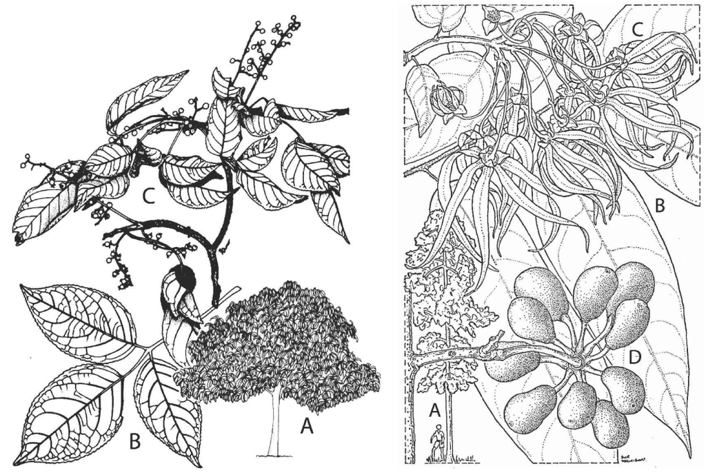

**Figure 7.7:** **Left** *Bischofia javanica*, Java cedar: **A**, tree; **B**, compound leaf; **C**, branch bearing cluster of fruit. **Right** *Cananga odorata*, ylang-ylang: **A**, tree; **B**, leaves; **C**, flowering shoot; **D**, fruit cluster.

| **PEOc** |  | *koka | ‘tree sp., *Bischofia javanica*’ (POLLEX) |
| --- | --- | --- | --- |
| SES | Ulawa | *ʔoʔa* | ‘*Bischofia javanica*’ (W. McClatchey, pers. comm.) |
| NCV | Tangoa | *(vi)ɣauha* | ‘*Bischofia javanica*’ |
| NCV | Raga | *(i)ɣoɣa* | ‘*Bischofia javanica*’ (Walsh 2004) |
| NCV | Lewo | *(puru)koa* | ‘*Bischofia javanica*’ |
| NCV | Nguna | *na-koka* | ‘tree sp.’ |
| NCV | Namakir | *na-koka* | ‘*Bischofia javanica*’ |
| NCV | South Efate | *n-kok* | ‘*Bischofia javanica*’ |
| **PCP** |  | *koka | ‘tree sp., *Bischofia javanica*’ |
| Fij | Wayan | *koka* | ‘*Bischofia javanica*’ |
| Fij | Bauan | *koka* | ‘*Bischofia javanica*’ |
| Pn | Tongan | *koka* | ‘*Bischofia javanica*’ |
| Pn | Niuean | *koka* | ‘small tree, *Baccaurea seemannii*’ |
| Pn | East Futunan | *koka* | ‘*Bischofia javanica*’ |
| Pn | East Uvean | *koka* | ‘*Bischofia javanica*’ |
| Pn | Ifira-Mele | *koka* | ‘*Bischofia javanica*’ |
| Pn | Rarotongan | *koka* | ‘*Bischofia javanica*’ |
| Pn | Māori | *koka* | ‘some edible plant’ |

### 5.2. *Cananga odorata*, ylang-ylang, perlume tree, *nandingori*, *nadingro*, *nangungara* (Annonaceae)

*Cananga odorata* (Figure 7.7, right) is usually a lower canopy tree 10–15 metres tall, but sometimes it reaches the canopy at 30 or 35m (Peekel 1984: 183, Conn & Damas 2006).

*Cananga odorata* is known across NW Island Melanesia (and elsewhere) for its fragrant yellow flowers, which are dried and used to scent coconut oil (Record 1945, Henderson & Hancock 1988:244, Hviding 2005: 130).

In northern Vanuatu the trunk is hollowed out and used for making drums and the branches are used for outriggers (Gowers 1976:43, Jauncey (in progress)). Kwa’ioloa & Burt (2001: 119) and Wheatley (1992: 42), on the other hand, say that the wood is too soft to be durable and is useful only for internal construction in places with a smoky atmosphere.

Use of the bark and flowers for medicinal purposes is widespread (Floyd 1954, Hviding 2005: 130).

POc *(m,mʷ)aso(q)u may have denoted a taxon which included *Cananga odorata* (§4.2). POc *pʷi(r,R)a and PSOc *diŋori(q) both appear to have denoted *Cananga odorata* alone.

| **POc** |  | *pʷi(r,R)a | ‘*Cananga odorata*’ |
| --- | --- | --- | --- |
| MM | Lihir | *pir* | ‘*Cananga odorata*’ |
| MM | Petats | *bina* | ‘*Cananga odorata*’ |
| MM | Teop | *bina* | ‘*Cananga odorata*’ |
| Mic | Ponapean | *pʷur* | ‘*Cananga odorata*’ |
| Mic | Mokilese | *pʷur* | ‘tree species’ |

| **PSOc** |  | *diŋori(q) | ‘*Cananga odorata*’ (Clark 1996; Lynch 2004a) |
| --- | --- | --- | --- |
| NCV | Mwotlap | *(na-tweh) dıŋıy* | ‘*Cananga odorata*’ (François 2004b) |
| NCV | Dorig | *(wa)dŋʋr* | ‘*Cananga odorata*’ (François 2004b) |
| NCV | Ambae | *diŋori* | ‘*Cananga odorata*’ |
| NCV | Tangoa | *(ve)riŋori* | ‘*Cananga odorata*’ |
| NCV | Kiai | *kinori* | ‘*Cananga odorata*’ |
| NCV | Tamambo | *(vu)diŋori* | ‘*Cananga odorata*’ |
| NCV | Raga | *diŋori* | ‘*Cananga odorata*’ |
| NCV | Paamese | *a-reŋe* | ‘*Cananga odorata*’ |
| SV | Kwamera | *nu-rəŋri* | ‘tree, sp. wood used for pierced ear and septum ornaments’ |

### 5.3. *Cryptocarya* sp. (Lauraceae)

The genus *Cryptocarya* consists of laurel-like evergreen plants which range in size from lower canopy shrubs to giant emergent trees (Conn & Damas 2006).

The sources of the data supporting POc *nipus ‘*Cryptocarya* sp.’, O’Collins & Lamothe (1989) and Damon (2004), do not provide enough information to allow a species identification, but O’Collins and Lamothe mention that the timber is used in house-building on Manus Island, implying that the species is not too small.[^18]: The sources of the data supporting PWOc *ka(m,mʷ)apaR tell us that the Muyuw tree is more than 10 m tall, the Patpatar tree, dubbed *Cryptocarya kamahar* by Peekel, 20–30 m tall.

Damon (In preparation) mentions that the nuts have a rich cinnamon-like smell and are important for medicinal purposes on Woodlark Island. Curiously, Muyuw people do not know the tree, as it grows away from areas they frequent, but they know its nuts because birds swallow them whole, then excrete them in their nests, complete with the endocarp, whence they are collected.

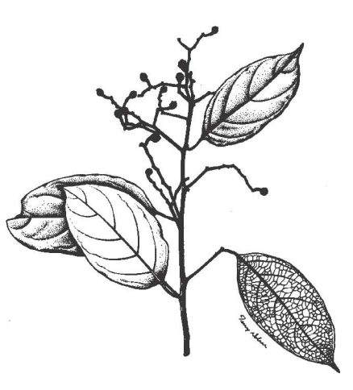

**Figure 7.8:** *Cryptocarya aromatica*.

| **POc** |  | *nipus | ‘*Cryptocarya* sp.’ |
| --- | --- | --- | --- |
| Adm | Bipi | *ñeu* | ‘*Cryptocarya* sp.’ |
| Adm | Nyindrou | *nip* | ‘*Cryptocarya* sp.’ |
| PT | Muyuw | *ni-niwous* | ‘*Cryptocarya* sp.’ |

| **PWOc** |  | *ka(m,mʷ)apaR | ‘*Cryptocarya* sp.’ |
| --- | --- | --- | --- |
| PT | Muyuw | *(ka)kamʷeya* | ‘*Cryptocarya* sp.’ |
| MM | Patpatar | *kamahar* | ‘*Cryptocarya kamahar*’ |

### 5.4. *Dillenia* sp. (Dilleniaceae)

| **PMP** |  | *de(k,g)el | ‘small *Dillenia* species’ |
| --- | --- | --- | --- |
| **POc** |  | *drokol | ‘small *Dillenia* species’ |
| **PSV** |  | *ne-dɣol | ‘*Dillenia biflora*’ (Lynch 2004a) |
| SV | Sye | *ne-tɣul* | ‘small *Dillenia* species’ |
| SV | Anejom̃ | *ne-cɣel* | ‘small *Dillenia* species’ |

### 5.5. *Diospyros* spp., ebony, blackwood, B *blakwud* (Ebenaceae)

*Diospyros* species are sub-canopy trees around 10 m tall with very hard black wood. *Diospyros peekelii* is used on New Britain for digging sticks, on New Ireland to make clubs for shark-catching (Floyd 1954, Peekel 1984: 432–433). In the western Solomons the wood of some species is used for carving (Hviding 2005: 142). The fruit of *Diospyros* species is the persimmon. The fruit of some species are edible and are eaten when other food is scarce (Record 1945).

Although *Diospyros* species are well known sub-canopy trees, widely mentioned in the literature, the only reconstruction that has proven possible is PSOc *numo. Otherwise only very local cognate sets are found, raising the possibility that the more important species have been introduced since POc times.

| **PSOc** |  | *numo | ‘*Diospyros* spp.’ (Lynch 2004a) |
| --- | --- | --- | --- |
| NCV | Mwotlap | *(ɣ[ʋ])nʋm* | ‘*Diospyros ferrea*’ |
| **Proto South Melanesian** |  | *n(e,i)mo | ‘*Diospyros* spp.’ (Lynch 2004a) [^20] |
| SV | Sye | *nimu(ŋlei)* | ‘*Diospyros ferrea*’ |
| NCal | Jawe | *(ce)nemo* | ‘*Diospyros austro-caledonicus*’ |
| NCal | Fwâi | *(ce)nuum* | ‘*Diospyros parviflora*’ |
| NCal | Nemi | *(ce)nuum* | ‘*Diospyros parviflora*’ |
| NCal | Jawe | *(ce)nuum* | ‘*Diospyros parviflora*’ |

### 5.6. *Euodia* spp. (Rutaceae)

Borrell (1989: 130–131) finds 14 species of *Euodia*[^21]: on Kairiru, ranging from small shrubs a metre high to the medium-sized tree, *Euodia elleryana* (syn. *Euodia tetragona*, *Melicope elleryana*), 15-20 m tall, with a soft white wood that has an unpleasantly musty smell and masses of rose-pink flowers (Peekel 1984: 270).

Peekel reports that larger trunks were used on New Ireland for small outrigger canoe hulls. The wood splits easily and is good for planks (Hviding 2005: 104).

Although POc *bala below is supported by only two reflexes, the notes provided by Kwa’ioloa & Burt (2001: 158) are informative. Kwara’ae *bala* is a generic term for species which include *bala ni kwaru* [bala of rock] ‘*Euodia elleryana*’, *bala kwau* (lit. ‘white *Euodia*’ ) or *bala fufuri* (lit. ‘patchy *Euodia*’), and simply *bala*. The authors provide a scientific name only for the first of the three. Apparently excluded from the bala taxon is *Euodia hortensis*, Kwara’ae *foʔoka* or *foʔaka*, which has complex ritual uses both here and at other localities. It is possible that POc *bala also denoted a taxon of *Euodia* species, the more so as Motu *ebala* denotes *Euodia hortensis*, the one species that Kwara’ae *bala* excludes.

| **POc** |  | *bala | ‘taxon including various *Euodia* spp.’ (?) |
| --- | --- | --- | --- |
| PT | Motu | *(e)bala* | ‘*Euodia hortensis*’ (Lane-Poole 1925) |
| SES | Kwara’ae | *bala* | ‘*Euodia* spp.’ |

A reasonable (but not the only) interpretation of the data below is that POc *bosi denoted a forest tree with white wood, perhaps *Euodia elleryana*, as the Meso-Melanesian data suggest, and was reapplied to another tree with white wood, *Alphitonia zizyphoides*, in southern Vanuatu.

| **POc** |  | *bosi | ‘a forest tree with white wood, probably *Euodia elleryana*’ |
| --- | --- | --- | --- |
| **Proto Northwest Solomonic** |  | *bosi | ‘*Euodia* spp.’ |
| MM | Nehan | *bouh* | ‘*Euodia hortensis*’ |
| MM | Nduke | *bosi* | ‘*Euodia elleryana*’ |
| MM | Marovo | *bosi* | ‘trees of lowland or secondary forest, *Euodia* spp.’ |
| MM | Roviana | *bosi* | ‘*Euodia elleryana*’ (Record 1945) |
| **PSV** |  | *na-bʷus(Vn) | ‘whitewood, *Alphitonia zizyphoides*’ (Lynch 2001c) |
| SV | Sye | *na-mpo* | ‘*Alphitonia zizyphoides*’ |
| SV | Kwamera | *na-pa* | ‘*Alphitonia zizyphoides*’ |
| SV | Kwamera | *na-pʷesən* | ‘*Alphitonia zizyphoides*’ |
| SV | Anejom̃ | *na-pʷoθ* | ‘*Alphitonia zizyphoides*’ |

Despite the fact that the shrub *Euodia hortensis* (island musk) is often cultivated and occurs in varieties with acrid-smelling leaves of various shapes, green or yellow, which are used to keep flies away and employed for various medicinal and ritual purposes at many localities (Ivens 1927:362, Peekel 1984: 267-268, Whistler 1991b: 133, Whistler 2000: 119, Wheatley 1992: 91, Hviding 2005: 106; ch.9, §2.1), the only term reconstructed for *Euodia hortensis* is PCP *usi.

| **PCP** |  | *usi | ‘*Euodia hortensis*’ |
| --- | --- | --- | --- |
| Fij | Bauan | *uði* | ‘*Euodia hortensis*’ |
| Pn | Tongan | *uhi* | ‘*Euodia hortensis*’ |
| Pn | Samoan | *usi* | ‘*Euodia hortensis*’ (W. McClatchey, pers. comm.) |

### 5.7. *Kleinhovia hospita*, puzzle tree, guest tree, B *namatal* (Sterculiaceae)

*Kleinhovia hospita* is a small to medium-sized tree. In New Ireland it usually grows to 6-10 m tall, but is sometimes as tall as 20-30 m in primary forest (Peekel 1984: 373). A striking feature is its short, branching bole: ‘it sprouts into many trees’ in the words of Kwa’ioloa & Burt (2001: 135).

There is remarkable agreement across sources about its uses, which do not vary much from the Bismarck Archipelago to Vanuatu. Its bast (fibrous inner bark) serves as temporary binding material. The soft light timber provided by young straight branches is used for rafters and internal construction. It also provides excellent firewood, and trees are sometimes ringbarked to turn them into convenient fuel sources. It is reputed to be one of the best woods for starting fires by traditional friction methods (another is the small forest tree *Callicarpa pentandra* according to Kwara’ae lore) (Powell 1976, Henderson & Hancock 1988: 158-159, Arentz et al. 1989: 94, Wheatley 1992: 225, Kwa’ioloa & Burt 2001: 135, Hviding 2005: 115-116).

Fewer sources mention medicinal uses: the Bola of New Britain use an infusion of the bark, and the leaves are used medicinally in Vanuatu (Powell 1976, Wheatley 1992: 225).

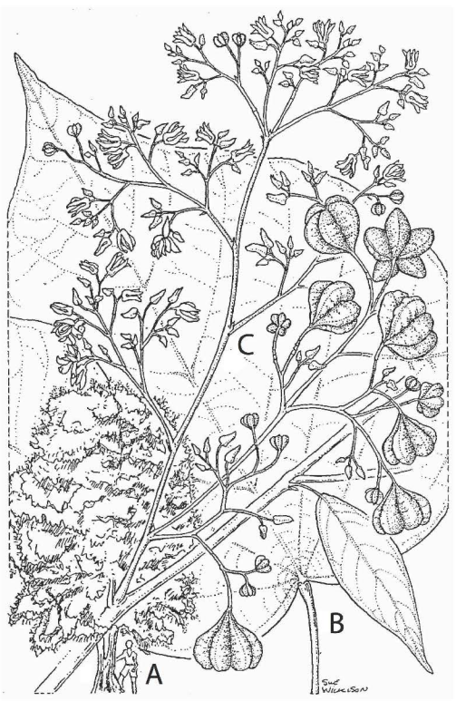

Most of the terms below are from NCV languages, and they present a minor puzzle. Lynch (2004a) divides them into two groups and makes two resemblant but seemingly irreconcilable PNCV reconstructions, *ma(t,d)aka (Banks, Malakula, Epi) and *matala (Banks, Santo, Malakula, Paama, Efate). There are also MM and SES reflexes, however, and here the terms reflect POc *ma(i)tagaR(a). Lynch’s PNCV *ma(t,d)aka, modified here to *ma(t,d)aga, reflects this unproblematically. This leaves Lynch’s PNCV *matala, which I take to reflect an early borrowing from a language which had lost *-k- but retained *-R- as *-l-* (the SES languages of Malaita reflect this pattern of reflexes, but there is no good reason to suppose that a language descended from the borrowing source still exists).

| **POc** |  | *ma(i)tagaR(a) | ‘*Kleinhovia hospita*’ |
| --- | --- | --- | --- |
| MM | Bola | *maitaga* | ‘*Kleinhovia hospita*’ (Arentz et al. 1989: 94) |
| MM | East Kara | *mətəkək* | ‘*Kleinhovia hospita*’ |
| MM | Patpatar | *matakara* | ‘*Kleinhovia hospita*’ |
| SES | Lengo | *mataga* | ‘*Kleinhovia hospita*’ (Henderson and Hancock 1988) |
| SES | Santa Ana | *magaka* | ‘*Kleinhovia hospita*’ (metathesis of PSES *mataga) |
| **PNCV** |  | *ma(t,d)aga | ‘*Kleinhovia hospita*’ |
| NCV | Mwotlap | *na-mʷtak* | ‘*Kleinhovia hospita*’ |
| NCV | Mota | *mʷataka* | ‘tree sp.’ |
| NCV | Uripiv | *mʷirek* | ‘*Kleinhovia hospita*’ |
| NCV | Naman | *midag* | ‘*Kleinhovia hospita*’ |
| NCV | Neve’ei | *na-mdaŋ* | ‘*Kleinhovia hospita*’ |
| NCV | Tape | *medek* | ‘*Kleinhovia hospita*’ |
| NCV | Avava | *midaŋ* | ‘*Kleinhovia hospita*’ |
| NCV | Larëvat | *medrak* | ‘*Kleinhovia hospita*’ |
| NCV | Nese | *no-murak* | ‘*Kleinhovia hospita*’ |
| NCV | Lewo | *(puru)mante* | ‘*Kleinhovia hospita*’ |
| NCV | Baki | *(buru)minda* | ‘*Kleinhovia hospita*’ |

| **PNCV** |  | *matala | ‘*Kleinhovia hospita*’ (Lynch 2004a) |
| --- | --- | --- | --- |
| NCV | Vurës | *matal* | ‘*Kleinhovia hospita*’ |
| NCV | Kiai | *matala* | ‘*Kleinhovia hospita*’ |
| NCV | Nokuku | *metal* | ‘*Kleinhovia hospita*’ |
| NCV | Sakao | *ne-ntal* | ‘*Kleinhovia hospita*’ |
| NCV | Araki | *(vi)mʷarala* | ‘*Kleinhovia hospita*’ |
| NCV | Tamambo | *(vu)matala* | ‘tree sp .’ |
| NCV | Raga | *matala* | ‘*Kleinhovia hospita*’ |
| NCV | Raga | *matala* | ‘*Kleinhovia hospita*’ |
| NCV | Port Sandwich | *madre* | ‘*Kleinhovia hospita*’ (J. Lynch, pers. comm.) |
| NCV | Aulua | *medel* | ‘*Kleinhovia hospita*’ (J. Lynch, pers. comm.) |
| NCV | Paamese | *merai* | ‘tree sp. used to make bow’ |
| NCV | Nguna | *na-matal* | ‘*Kleinhovia hospita*’ |
| NCV | South Efate | *na-matal* | ‘*Kleinhovia hospita*’ |

PMM *p(i,u)lakis and POc *paqu, both ‘*Kleinhovia hospita*’, are also reconstructable. The forms under ‘cf also’ appear to reflect a variant *paqi which may represent a conflation of the two etyma.

| **PMM** |  | *p(i,u)lakis | ‘*Kleinhovia hospita*’ |
| --- | --- | --- | --- |
| MM | Bola | *bulai* | ‘*Kleinhovia hospita*’ (for †*pulai*) |
| MM | Nehan | *hule* | ‘*Kleinhovia hospita*’ |
| MM | Babatana | *vilaki* | ‘*Kleinhovia hospita*’ (McClatchey et al. 2005) |
| MM | Nduke | *valakihi* | ‘*Kleinhovia hospita*’ |
| SES | Bugotu | *vare* | ‘*Kleinhovia hospita*’ (for †*vale*; perhaps borrowed from a MM language) |

| **POc** |  | *paqu | ‘*Kleinhovia hospita*’ |
| --- | --- | --- | --- |
| MM | Tolai | *vau* | ‘*Kleinhovia hospita*’ (Record 1945) |
| MM | Roviana | *paɣo* | ‘*Kleinhovia hospita*’ (Record 1945) |
| NCV | Lakon | *vʋɣ-vʋɣ* | ‘*Kleinhovia hospita*’ (François 2004) |
| Fij | Wayan | *vau* | ‘*Kleinhovia hospita*’ |

cf. also:

| MM | Mono-Alu | *(la)hai* | ‘*Kleinhovia hospita*’ |
| --- | --- | --- | --- |
| SES | Lau | *fai-fai* | ‘*Kleinhovia hospita*’ |
| SES | Kwara’ae | *fae-fae* | ‘*Kleinhovia hospita*’ |
| SES | Kwaio | *fae-fae* | ‘tree sp.’ |

### 5.8. *Litsea* spp. (Lauraceae)

Numerous *Litsea* species of varying statures occur in the Bismarcks and the Solomons. If POc *lowaŋa, reconstructed below, did indeed denote a particular species of *Litsea*, then O’Collins & Lamothe (1989) indicate that it was one large enough to make a canoe hull. Of the species listed by Peekel (1984: 191), two qualify: *Litsea kauloensis* and *Litsea dielsiana*, each 15-20 m tall.

The reconstruction of PCEMP/POc *lowaŋa ‘*Litsea* sp.’ is made possible by the CMP reflexes recorded by Verheijen (1990: 224): Kepo, Rembong (both CMP) *lowaŋ* ‘*Litsea* sp.’. Although Nakanai *loaga* ‘*Gmelina* sp.’ is glossed as another species, both are used for canoe hulls, and the Nakanai term is almost certainly cognate with Nyindrou *lowaŋ*. Nakanai also provides us with the final vowel for the reconstruction; that there was a final vowel can be inferred from the fact that final consonants are lost in Nyindrou and in the CMP languages from which reflexes are drawn.

| **PCEMP** |  | *lowaŋa | ‘*Litsea* sp.’ |
| --- | --- | --- | --- |
| **POc** |  | *lowaŋa | ‘*Litsea* sp.’ |
| Adm | Nyindrou | *lowaŋ* | ‘*Litsea* sp.’ (O’Collins and Lamothe 1989) |
| MM | Nakanai | *loaga* | ‘*Gmelina* sp.’ |

### 5.9. *Myristica* spp., wild nutmeg, B *nandae* (Myristicaceae)

The most famous *Myristica* species is the nutmeg, but its easternmost extent is West Papua (Warburg 1899: 57). Among the species of wild nutmeg which grow in the Bismarcks are *Myristica schleinitzii*, a small foreshore tree 3-6 m tall, and *Myristica fatua*, a sub-canopy tree reaching 20m on New Ireland (Peekel 1984: 185). *Myristica fatua* is a canopy tree in some areas, e.g. in Kwara’ae country. Both species prefer a damp environment and have stilt roots even in dry locations (Paijmans 1976: 37). POc *(dr,d)aRa(q,k)a presumably denoted at least one of these two species and perhaps a taxon including a number of *Myristica* species.

The soft wood of both species makes planking for indoor use and good firewood in locations from New Britain to Vanuatu (Floyd 1954, Powell 1976, Wheatley 1992:172-174, Kwa’ioloa & Burt 2001: 120, 167).

With regard to reconstructing a PROc term for *Myristica fatua* Lynch (2004a) writes:

> The Banks and Raga forms suggest *draRaka, other NCV languages something like *draRaqi, while the SV forms point rather to PSOc *d(r)ani, *d(r)aRani or *d(r)aqani. Ross Clark (pers. comm.) has suggested a possible connection to words meaning ‘blood’, from POc *draRaq: Wheatley (1992: 172) refers to the ‘dark red exudate’ of the inner bark, and Codrington relates Mota *naraa* to *nara* ‘blood’. The S Efate form is also homophonous with ‘blood’, and the SV forms almost so (PSV *n-da(q,V), *n-da(a)-). The form may thus be based on the POc term for ‘blood’ [*draRaq], and be something like *draRaq-(n)(i,a).

To Lynch’s Southern Oceanic cognate set we add Western Oceanic and Kwara’ae (SES) items. Reconstructing a POc etymon from these data is tricky, as they do not lead to an unambiguous reconstruction, yet they probably all reflect a single etymon.

Lynch’ s discussion points to three phonological questions:

- the third consonant: was it POc *k or *q?
- the third vowel: was it POc *a or *i?
- what is the source of PSV *n?

To these we can add a fourth not raised by Lynch’s data:

- the initial consonant: was it POc *dr or *d?

I address the last question first. All reflexes except Muyuw, Lihir and Kwara’ae point to either *dr- or *d-. Muyuw *a-yayak* and Lihir *lala*, however, reflect initial POc *r- or *R-. These probably reflect assimilation to the medial reflex of *-R-, so they do not help us to disambiguate the initial. Distinguishing reflexes of *d from those of *dr is difficult, because *d was a very low-frequency POc consonant: for some languages we have no reflex of *d, and in some others it merges with *dr. The one language that helps us with this disambiguation is Kwara’ae, where *ka-kalaʔa* at first sight seems to reflect POc *g-. However, a small number of SE Solomonic lexical items reflect POc *d (but apparently not *dr) as if it were *g, and this is evidently one of them. This suggests that the initial consonant was *d- and that resemblances to the word for ‘blood’ are accidental, but perhaps amplified by folk-etymologising, since the blood-like colour of *Myristica* sap is widely recognised.[^22]:

The second question to be addressed concerns the third consonant: was it POc *k or *q? As Lynch notes, the Banks and Raga reflexes (the first six NCV reflexes below) point to *k. So does Muyuw *a-yayak*. Other reflexes point to *q. If changes in form took place as a result of folk-etymologising, then reflexes of *q may be due to reflexes of POc *draRaq ‘blood’, leaving *k as the more likely proto-consonant.

The other two questions-was the third vowel *a or *i? what is the source of PSV *n? - may be taken together. Four items below, Kwara’ae *ka-kalaʔa*, Vera’a *daraɣa*, Mota *na-raɣa* and Raga *a-oaɣa* suggest that the vowel was *a, i.e. they point to POc *(dr,d)aRaka. On the other hand NE Ambae *dadai* and Uripiv *drari* reflect a final *-i in *(dr,d)aRaq(a)-i, and PSV *na-(dr,d )ani reflects a final *-ni in *(dr,d )aRaq(a)-ni (these are languages in which both *R and *q are lost). The altemation between final *-i and *-ni is suggestive, as both are reflected in variants of the so-called associative: (non-specific possessor) construction. Thus ‘blood of tree’ would have been expressed in POc as *(dr,d)aRaq i kayu or *(dr,d)aRaq ni kayu, depending on whether *(dr,d)aRaq was directly or indirectly possessed; either *i or *ni has been generalised to both in various daughter-languages (Ross 1998b). The suggestion is that *-i- and *-ni_ are accretions brought about by the truncation of something like ‘blood of tree’, itself an outcome of folk etymology, and that they are therefore not part of the POc reconstruction.

The reconstruction that emerges from the discussion above is POc *daRaka, but there is enough speculation above to commend prudence, and so I offer POc *(dr,d)aRa(q,k)a below.

| **POc** |  | *(dr,d)aRa(q,k)a | ‘wild nutmeg, *Myristica* sp.’ |
| --- | --- | --- | --- |
| PT | Muyuw | *(a)yayak* | ‘*Myristica schleinitzii*’ |
| MM | East Kara | *de* | ‘*Myristica fatua*’ |
| MM | Lihir | *lala* | ‘*Myristica* sp.’ (Burley 2006) |
| SES | Kwara’ae | *ka-kalaʔa* | ‘*Myristica fatua*’ |

| **PNCV** |  | *(dr,d)aRa(q,k)(a,i) | ‘wild nutmeg, *Myristica* sp.’ |
| --- | --- | --- | --- |
| NCV | Mota | *na-raɣa* | ‘nutmeg’ |
| NCV | Mwotlap | *na-d[a]yaɣ* | ‘*Myristica fatua*’ (François 2004b) |
| NCV | Vera’a | *daraɣa* | ‘*Myristica fatua*’ (François 2004b) |
| NCV | Vurës | *daraɣ* | ‘*Myristica fatua*’ (François 2004b) |
| NCV | Mwesen | *(wo)na-raɣ* | ‘*Myristica fatua*’ (François 2004b) |
| NCV | Raga | *(a)oaɣa* | ‘*Myristica fatua*’ |
| NCV | Ambae | *dadai* | ‘*Myristica fatua*’ |
| NCV | Uripiv | *drari* | ‘*Myristica fatua*’ |
| NCV | South Efate | *n-ra* | ‘*Myristica fatua*’ |
| **PSV** |  | *na-(dr,d)ani | ‘wild nutmeg, *Myristica fatua*’ (Lynch 2004a) |
| SV | Sye | *na-nre* | ‘*Myristica fatua*’ |
| SV | Lenakel | *ne-tan* | ‘*Myristica fatua*’ |
| SV | Kwamera | *n-tan* | ‘*Myristica fatua*’ |
| SV | Anejom̃ | *na-jeñ* | ‘*Myristica fatua*’ |

### 5.10. *Parinari* spp., putty nut (Chrysobalanaoeae)

Finding one’s way through the maze of synonymous scientific names for Bismarcks species of the genus *Parinari* is difficult, but it appears that in NW Island Melanesia there are two similar species which were perhaps treated as a single POc taxon, *(q,k)atita:[^23]:

- *Parinari laurina* (syn. Cyclandrophora laurina, *Atuna racemosa*) and
- *Parinari glaberrima* (syn. *Maranthes corymbosa*, *Parinari corymbosa*, *Parinari griffithiana*) (Figure 7.10, left)[^24]:

*Parinari laurina* seems to be more common in the Bismarcks, *Parinari glaberrima* in the Solomons. Both are small to medium-sized sub-canopy trees, 10–20 m tall. Their large nuts have a hard shell. After it has been broken, the tough kernel of the fruit is rubbed over a rough surface to produce small crumbs of putty-like mash, and the resulting sticky putty is used to caulk plank canoes, to seal and repair cracks in dugouts, and to fasten shell inlays to wood carvings. After drying, this coating forms a firm, watertight and breakable-resistant layer (Holdsworth & Wamoi 1981, Peekel 1984:202-203, Henderson & Hancock 1988:230-232, Ohnemus 1998, Kwa’ioloa & Burt 2001: 165, Hviding 2005: 147).

In the Carolines a decoction of the pericarp of the *Parinari laurina* fruit is used for painting canoes red (Christian 1899: 328). In Fiji its long straight branches are used for canoe paddles and as houses rafters. Its leaves are used to fill in the outer walls of houses (Capell 1941). In the Solomons the bark provides a medicine taken against diarrhoea or dysentery (Henderson & Hancock 1988: 232).

Reconstructing the POc term for the putty nut is a little tricky, as Chowning (2001: 76) mentions in a footnote, because Oceanic languages appear to reflect three related forms: *qatita, *katita and *tita. The Admiralties forms below may reflect either POc *katita or

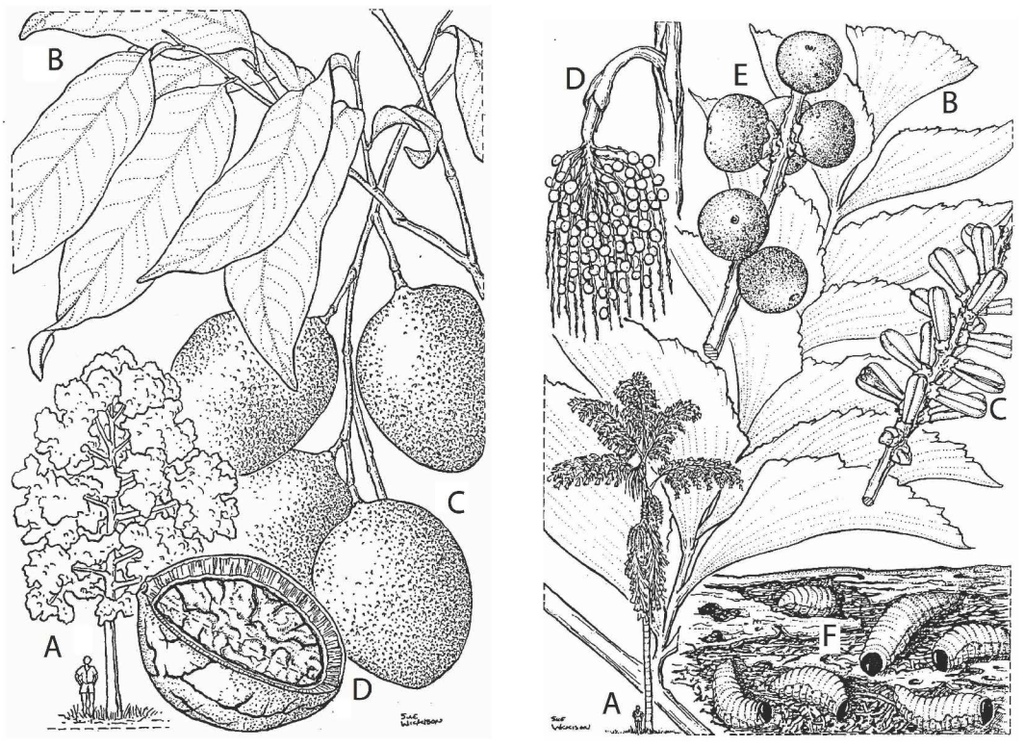

**Figure 7.10:** **Left** *Parinari* glaberrima: **A**, tree; **B**, shoot bearing one mature and one old inflores- cence; **C** and **D**, nut. **Right** *Caryota rumphiana*: **A**, tree; **B**, leaflet; **C**, portion of inflorescence; **D**, fruiting inflorescence; **E**, fruit; **F**, larvae of Rhynocaphorus beetle in a rotting trunk.

POc *qatita. Of the Western Oceanic forms, Wogeo *kətita* and Kara *katita* reflect *katita, whilst the rest may reflect either *katita or *qatita. On the simplest interpretation of the data I reconstruct PWOc *katita. The Eastern Oceanic forms, on the other hand, reflect *qatita. POc *(q,k)atita below reflects this ambiguity.

| **POc** |  | *(q,k)atita | ‘the putty nut, probably *Parinari laurina* and *Parinari glaberrima*’ (ACD: *qatita) |
| --- | --- | --- | --- |
| Adm | Likum | *ketik* | ‘putty nut, *Parinari laurina*’ |
| Adm | Drehet | *ketik* | ‘putty nut, *Parinari laurina*’ |
| Adm | Lou | *kerit* | ‘putty nut, *Parinari laurina*’ |
| **PWOc** |  | *katita | ‘the putty nut, probably *Parinari laurina* and *Parinari glaberrima*’ |
| NNG | Kove | *atita* | ‘putty nut, *Parinari laurina*’ |
| NNG | Wogeo | *kətita* | ‘putty nut, *Parinari laurina*’ |
| NNG | Kilenge | *atita* | ‘putty nut, *Parinari laurina*’ |
| MM | East Kara | *katita* | ‘putty nut, *Parinari laurina*’ |
| MM | Tolai | *katita* | ‘putty nut, *Parinari laurina*’ |
| MM | Tinputz | *acic* | ‘putty nut, *Parinari laurina*’ |
| MM | Teop | *asita* | ‘putty nut’ |
| **PEOc** |  | *qatita | ‘the putty nut, probably *Parinari laurina* and *Parinari glaberrima*’ |
| SES | Baegu | *saia* | ‘putty nut’ |
| SES | Kwara’ae | *saia* | ‘putty nut, *Parinari glaberrima*’ |
| SES | Sa’a | *saie* | ‘putty nut’ |
| SES | Lau | *saia* | ‘putty nut, *Parinari glaberrima*’ |
| SES | Kwaio | *laia* | ‘putty nut’ |
| SES | ’Are’are | *raia* | ‘putty nut’ |
| Mic | Carolinian | *ais* | ‘putty nut, *Parinari laurina*’ |
| Mic | Chuukese | *ayis* | ‘*Parinari* tree’ |
| Mic | Woleaian | *yaise* | ‘tree sp. with fragrant fruit’ |
| Mic | Ponapean | *ays* | ‘*Parinari* tree’ |

Blust (ACD) reconstructs doublets *qatita and *qarita for this item. Supporting data for medial *-r-, however, are drawn entirely from Admiralties languages and Mussau, a distribution which does not justify a POc reconstruction on the criteria set out in ch. 1, §3.2.3. Instead, it seems likely that the forms listed below which appear to reflect *qarita are the result of borrowing(s) from a language or languages that reflects (or reflected) POc *-t- as *-r-*. There are a number of these in the Admiral1cies: Lou, Penchal, Baluan, Lenkau, Pak, Koro, Nali, Lele and Ponam (Ross 1988: 322) (among the data above only Lou has *-r-* in a directly inherited reflex of *qatita).

Among directly inherited Admiralties reflexes of *qatita, those in Likum, Drehet and Lou have initial *k-*. The reflexes below, however, agree not only in appearing to reflect *-r- but also in loss of the initial consonant. This suggests that they may all reflect a single early borrowing of a form *arita.

| Adm | Mussau | *arita* | ‘putty nut’ |
| --- | --- | --- | --- |
| Adm | Nyindrou | *alik* | ‘putty nut, *Parinari laurina*’ |
| Adm | Nauna | *alit* | ‘putty nut, *Parinari laurina*’ |
| Adm | Penchal | *alit* | ‘putty nut, *Parinari laurina*’ |
| Adm | Pak | *ehir* | ‘putty nut, *Parinari laurina*’ |
| Adm | Nali | *n-alit* | ‘putty nut, *Parinari laurina*’ |
| Adm | Ere | *arit* | ‘putty nut, *Parinari laurina*’ |
| Adm | Titan | *alit* | ‘putty nut, *Parinari laurina*’ |
| Adm | Sori-Harengan | *ahiʔ* | ‘putty nut, *Parinari laurina*’ |
| Adm | Leipon | *yerit* | ‘putty nut, *Parinari laurina*’ |
| Adm | Loniu | *eit, aʔat* | ‘putty nut, *Parinari laurina*’ |

A number of Meso-Melanesian reflexes lack the initial syllable, reflecting a possible PMM altemant *tita.[^25]: For clarity’s sake these are listed separately below. There are also two SE Solomonic reflexes of *tita, in Gela and Bugotu, but both languages are prone to borrow from NW Solomonic (and thus Meso-Melanesian) neighbours.

Attempting to account for *tita Blust (ACD) suggests that the initial syllable has been irregularly lost. He puts forward two possible reasons for such a loss. First, POc roots were predominantly disyllabic, and this is true of many daughter-languages: this might favour foreshortening. Second, the POc common article was *a or *na. If initial *k- or *q- was lost from a reflex, then the resulting initial *a- could be reanalysed as part of the article. A third possible reason is offered here, namely that *ka- was reanalysed as the ‘tree’ prefix *ka-, leaving *tita as the name of the tree (ch.2, §7.1.2).

| **PMM** |  | *tita | ‘the putty nut, probably *Parinari laurina* and *Parinari glaberrima*’ (Chowning 1963) |
| --- | --- | --- | --- |
| MM | Nakanai | *tita* | ‘*Parinari glaberrima*’ |
| MM | Tolai | *tita* | ‘*Parinari laurina*’ |
| MM | Nehan | *tita* | ‘*Parinari laurina*’ |
| MM | Petats | *tic* | ‘*Parinari glaberrima*’ |
| MM | Teop | *tita* | ‘*Parinari glaberrima*’ |
| MM | Varisi | *sita* | ‘putty nut, *Parinari glaberrima*’ (W. McClatchey, pers. comm.) |
| MM | Simbo | *tita* | ‘*Parinari laurina*; gum, glue’ |
| MM | Nduke | *tita* | ‘*Parinari glaberrima*’ |
| MM | Marovo | *tita* | ‘*Parinari glaberrima*’ |
| MM | Roviana | *tita* | ‘*Parinari glaberrima*’ (Henderson and Hancock 1988) |
| SES | Bugotu | *tita* | ‘putty nut’ |
| SES | Gela | *tita* | ‘*Parinari* sp.’ |

cf. also:

| MM | Babatana | *lita* | ‘*Parinari glaberrima*’ |
| --- | --- | --- | --- |

The cognate set below appears at first sight to be related to Baegu, Kwara’ae, Sa’a and Lau *saia* above, but *saia* is the regular reflex of POc *qatita, since *q- and *-t- are both deleted, and *s-* is a regular accretion before the resulting initial *a-*, corresponding with Kwaio *l-* in *laia* and ’Are’are *r-* in *raia* (Frantisek Lichtenberk 1988). These changes are quite different from those regularly reflected in PCP.

| **PCP** |  | *sea | ‘tree, *Parinari insularum*’ (Milke (1961): POc) |
| --- | --- | --- | --- |
| Fij | Rotuman | *sea* | ‘tree sp.’ |
| Fij | Bauan | *sea* | ‘*Parinari insularum*’ |
| Pn | Tongan | *hea* | ‘*Parinari insularum*’ |
| Pn | East Futunan | *sea* | ‘*Parinari insularum*’ |
| Pn | East Uvean | *hea* | ‘*Parinari insularum*’ |
| Pn | Samoan | *sea* | ‘*Parinari insularum*’ |

It is not clear what connection (if any) the form below has with those above.

| **POc** |  | *maRakita | ‘the putty nut, probably *Parinari laurina* and *Parinari glaberrima*’ |
| --- | --- | --- | --- |
| MM | Mono-Alu | *malakita* | ‘putty nut, *Parinari glaberrima*’ (W. McClatchey, pers. comm.) |
| Fij | Wayan | *mākita* | ‘forest tree with large seeds used to caulk canoes, *Parinari laurina*’ |
| Fij | Bauan | *makita* | ‘putty nut, *Parinari laurina*’ |

### 5.11. Palms

#### 5.11.1. *Caryota rumphiana*, black palm, fishtail palm, TP *waillimbum* (Arecaceae)

*Caryota rumphiana* is the only palm in NW Island Melanesia with bipinnate fronds, i.e. the leaflets on either side of the midrib themselves have a central rib and are leaf-like (Figure 7.10, right). *Caryota rumphiana* stands 10–20 m high and has fruit the size of a cherry which hang in bunches from the top of its blackish trunk (Peekel (1984), Kwa’ioloa & Burt 2001: 187).

Throughout NW Island Melanesia, the trunks are split to make floorboards (Floyd 1954, Henderson & Hancock 1988: 150, Arentz et al. 1989: 93, Scales n.d. McEldowney 1995, Margetts 2005a). The wood is also used on New Britain for axe handles, clubs, bows and spears (Floyd 1954, Powell 1976). The pith from the young trunk is sometimes eaten on New Britain, and fed to pigs in the Solomons.

Henderson & Hancock (1988: 150) describe how inland dwellers in the Solomons use a felled *Caryota rumphiana* trunk to farm larvae of a large beetle of the genus Rhynocaphorus by cutting notches at 2 m intervals along it, harvesting the larvae and pupae 3–4 months later. For some households the larvae are a major source of protein, although others find the accompanying taste of the rotting palm core rather offensive.

The Oceanic data below were assembled by Blust (ACD). The reconstruction of PCEMP *bual(a) ‘*Caryota* sp.’ is based on these data and on W Sumba *ʔwuola*, E Sumba (both CMP) *ʔwuala* ‘*Caryota mitis*’ (Verheijen 1990: 199).

| **PCEMP** |  | *bual(a) | ‘*Caryota* sp.’ |
| --- | --- | --- | --- |
| **POc** |  | *[bual]bual | ‘species of palm used for making spears and bows; palm-wood spear or bow, probably *Caryota* sp.’ (ACD) |
| Adm | Lou | *(si)pua* | ‘black palm’ |
| PT | Tawala | *bua-bua* | ‘smalll tree fern, used for spears’ |
| PT | Saliba | *bua-bua* | ‘k tree, used for spears and sticks’ |
| MM | Lihir | *buer* | ‘fern sp.’ |
| MM | Roviana | *buala* | ‘large kind of bow’ |
| MM | Simbo | *buala* | ‘war bow’ |
| SES | Sa’a | *pue-pue* | ‘a palm used for making bows, combs, heavy spears’; ‘heavy palm-wood spear’ |
| SES | Sa’a | *pue-pue* | ‘a palm used for making bows, combs, heavy spears’; ‘heavy palm-wood spear’ |
| SES | Ulawa | *pua-pua* | ‘a palm used for making bows, combs, heavy spears’ |
| Pn | Hawaiian | *pua* | ‘arrow, dart, sometimes made from flower stalks of sugarcane’ |

PMP *katipa(l,n) below is reconstructed on the basis of the Oceanic data below and of Hanunuo, Mangyan (WMP) *katipan* ‘*Caryota cumingii*’ (Madulid 2001a: 364) and Wandamen (EMP) *kasira* ‘black palm sp.’ (Smits & Voorhoeve 1992: 222).

| **PMP** |  | *katipa(l,n) | ‘a palm with black wood, *Caryota* sp.’ |
| --- | --- | --- | --- |
| **POc** |  | *kati(p)al | ‘a palm with black wood, *Caryota* sp.’ |
| PT | Tawala | *kahiala* | ‘*Caryota* sp.’ |
| PT | Dobu | *kasiala* | ‘*Caryota* sp.’ |
| MM | Tinputz | *kacan* | ‘*Caryota* sp.’ |
| MM | Marovo | *kacuele* | ‘palm, *Drymophloeus* sp., black wood used for bows and spear tips’ |

Tiny though the cognate set below is, the membership of its two members in different primary subgroups of Oceanic justifies a POc reconstruction.

| **POc** |  | *j(o,u)abo | ‘*Caryota* sp.’ |
| --- | --- | --- | --- |
| Adm | Baluan | *soap* | ‘*Caryota rumphiana*’ |
| MM | Bali | *tuabo* | ‘*Caryota* sp.’ (Hide 1985) |

#### 5.11.2. *Licuala* spp., fan palm (Arecaceae)

The leaves of the small palm *Licuala ramsayi* (syn. *L. muelleri*, *L. peekelii*), growing to about 5-10 m, serve for roofing in parts of the Bismarcks (Powell 1976, Peekel 1984: 58). The Nakanai use them to wrap megapode eggs (A. Chowning, pers. comm.). The palm also serves decorative purposes: in the Ninigo Islands it is planted as an ornamental shrub (Sorensen 1950), and various writers note that its leaves are used for personal decoration.

POc *piRu denoted one or more *Licuala* species, a fan palm. As French-Wright (1983: 208-209) and Chowning (2001: 84) note, in Fijian and the Polynesian languages its reflexes denote the fan palm *Pritchardia pacifica*, found only in Fiji and Polynesia.[^26]: This is an instance of an established name being given to a new-found species as Oceanic speakers moved eastward.

On the basis of the non-Oceanic data supporting Blust’s reconstruction of PMP *biRuʔ (ACD), we would expect the POc form *piRu, and this is reflected everywhere except in northern Vanuatu, where a local form *piloqi is reflected. NCV forms sporadically retain a POc final consonant with an added *-i, regularly lost in Volow, Mota and Merlav, and so the final *-ɣ* of these items may reflect POc *-q, a possibility recognised in the reconstruction of POc *piRu(q).

| **PMP** |  | *biRuʔ | ‘fan palm, *Licuala rumphii*’ (ACD) |
| --- | --- | --- | --- |
| **POc** |  | *piRu(q) | ‘fan palm, *Licuala* sp.’ (ACD; Chowning 2001) |
| NNG | Kove | *pilu* | ‘*Licuala* sp.’ |
| MM | Nakanai | *vilu-vilu* | ‘*Licuala* sp.’ |
| MM | East Kara | *fi* | ‘*Licuala lauterbachii*’ |
| MM | Halia | *hil* | ‘*Licuala* sp.’ |
| MM | Solos | *hin* | ‘*Licuala* sp.’ |
| MM | Mono-Alu | *hiuru* | ‘*Licuala lauterbachii*’ (W. McClatchey, pers. comm.) |
| **PEOc** |  | *piRu(q) | ‘fan palm, umbrella palm’ (Geraghty 1990) |
| SES | Gela | *vilu* | ‘species of palm with umbrella-like leaves’ |
| SES | Lau | *filu* | ‘umbrella palm’ |
| SES | Kwaio | *filu* | ‘wild palm species used to make bows’ |
| SES | Kwara’ae | *filu* | ‘*Pritchardia pacifica*’ |
| SES | Kwara’ae | *filu tali* | ‘*Licuala lauterbachii*’ |
| SES | Sa’a | *hilu* | ‘a ridge covering of sago-palm leaves, laid on flat’ |
| SES | ’Are’are | *hiru* | ‘a palm tree with digital leaves, used for making bows’ |
| SES | Arosi | *hiru* | ‘a palm sp. used in making a war-bow’ |
| NCV | Volow | *(n-ye)ploɣ* | ‘*Licuala* sp., *Pritchardia pacifica*’ (François 2004b) |
| NCV | Mota | *viloɣ* | ‘an umbrella palm; a frond of that palm used as an umbrella’ |
| NCV | Dorig | *(dã)vlʋ* | ‘*Licuala* sp., *Pritchardia pacifica*’ (François 2004b) |
| NCV | Merlav | *(dʋ)vlʋɣ* | ‘*Licuala* sp., *Pritchardia pacifica*’ (François 2004b) |
| SV | Sye | *(lu)vor* | ‘*Pritchardia pacifica*’ |
| NCal | Xârâcùù | *pii* | ‘a kind of palm tree’ |
| **PCP** |  | *viu | ‘fan palm, umbrella palm, *Pritchardia pacifica*’ |
| Fij | Bauan | *viu* | ‘*Pritchardia pacifica*’ |
| Pn | Tongan | *piu* | ‘*Pritchardia pacifica*’ |
| Pn | Niuean | *piu* | ‘*Pritchardia pacifica*’ |
| Pn | East Uvean | *piu* | ‘*Pritchardia pacifica*’ |
| Pn | East Futunan | *piu* | ‘fan palm’ |
| Pn | Samoan | *piu* | ‘*Pritchardia pacifica*’ |
| Pn | Tokelauan | *piu* | ‘*Pritchardia pacifica*’ |

## 6. The shrub layer

The shrub layer is usually patchy because of lack of sunlight. A few small trees, up to a height of around 15m, grow here, as well as *Calamus* (§6.3.1), bamboos (ch.13, §3.1) and gingers (Henderson & Hancock 1988: 320).

### 6.1. Woody shrubs

#### 6.1.1. *Abroma augusta* (Sterculiaceae)

*Abroma augusta* is a small shrub 1-2m tall, more common in the highlands of New Guinea than in lowland forests (French 1986, Peekel 1984: 373). On Malaita its white bark is used to make hanging baskets (Kwa’ioloa & Burt2001: 160). In parts of New Britain its bast provides rope for pig nets and for lashing house components and material used in making clothing, and bags (Powell 1976, Lentfer 2003).

Reflexes of POc *wasi-wasi ‘*Abroma augusta*’ are found with this meaning only in Near Oceania. In Remote Oceania the name denotes a large forest tree, *Sterculia vitiensis* (ch. 11, §2.6), which does not occur in NW Island Melanesia. Will McClatchey (pers. comm.) suggests that the change in denotation was mediated by the fact that *Sterculia vitiensis* is also a source of fibre.

| **POc** |  | *wasi-wasi | ‘*Abroma augusta*’ |
| --- | --- | --- | --- |
| MM | East Kara | *(ka)us-vas* | ‘*Abroma augusta*’ |
| MM | Patpatar | *was-was* | ‘*Abroma augusta*’ |
| MM | Nehan | *ase-is* | ‘*Abroma augusta*’ |
| SES | Kwara’ae | *kʷasi-kʷasi* | ‘*Abroma augusta*’ |
| **PROc** |  | *wasi-wasi | ‘*Sterculia vitiensis*’ (from data in Wheatley 1992, Lynch 2004a) |
| NCV | Ambae | *wah-wah* | ‘*Sterculia vitiensis*’ |
| NCV | Tangoa | *(vitu)vaha* | ‘*Sterculia vitiensis*’ |
| NCV | Raga | *wahi-wahi* | ‘*Sterculia vitiensis*’ |
| NCV | Apma | *wah-wah* | ‘*Sterculia vitiensis*’ |
| NCV | Tape | *(vən)woso-wos* | ‘whitewood’ |
| SV | Sye | *wo-wo* | ‘*Sterculia vitiensis*’ |
| SV | Lenakel | *nə-vha-vha* | ‘*Sterculia vitiensis*’[^27] |
| SV | Anejom̃ | *n-woθ-waθ* | ‘*Sterculia vitiensis*’ |
| Fij | Buca Bay | *waði-waði* | ‘*Sterculia vitiensis*’ (J. Parham 1972; Buca Bay is in Vanua Levu) |

#### 6.1.2. *Angiopteris evecta* (syn. *Angiopteris erecta*), mule’s foot fern (Marattiaceae)

The plant with the largest fronds (1.5m long) on New Ireland, *Angiopteris evecta* is a large fern common in shady inland forest. The fronds rise from a massive rootstock, fleshy and moist, but fragrant when dry (Peekel 1984: 30). Because of their moisture, the Kwara’ae lay them out around garden boundaries to soften the soil in the belief that this will improve the quality of the taro (Kwa’ioloa & Burt 2001: 211).

| **PCP** |  | *nas(e,i) | ‘edible roots of certain plants ?’ (POLLEX2) |
| --- | --- | --- | --- |
| Fij | Bauan | *naði* | ‘the greater roots of the yaqona plant’ |
| **PPn** |  | *nas(e,i) | ‘giant fern, *Angiopteris evecta*, with edible root’ |
| Pn | Samoan | *nase* | ‘the giant ferns *Angiopteris evecta* and *Marattia fraxinea*’ |
| Pn | Marquesan | *nahe, nahi* | ‘root eaten in times of scarcity’ |
| Pn | Rarotongan | *naʔe* | ‘*Angiopteris evecta*’ |
| Pn | Tahitian | *nahe* | ‘*Angiopteris evecta*’ |

#### 6.1.3. *Donax cannaeformis* (syn. *Clinogyne grandis*, *Maranta grandis*, *Thalia cannaeformis*, *Actoplanes canniformis*, *Donax arundastrum*) (Marantaceae)

A leafy shrub, *Donax cannaeformis* has a rhizome from which rise erect smooth stems 1.5-3 m tall with spreading branches about 85cm long. It has elliptical leaves often with yellowish-white patches and white flowers and fruits, and grows in damp locations (Peekel 1984: 111). Its range is from SE Asia to the Solomons.

As the glosses below indicate, its stems are used in thatching, basket-making and as armlets.

| **PMP** |  | *niniq | ‘plant sp., *Donax cannaeformis*, used as material for making baskets’ (Blust 1989; ACD) |
| --- | --- | --- | --- |
| **POc** |  | *nini(q) | ‘shrub, *Donax cannaeformis*’ |
| MM | Bola | *(natala)nini* | ‘*Donax cannaeformis*’ |
| MM | Marovo | *nina* | ‘*Donax cannaeformis*’ |
| MM | Ririo | *nina* | ‘*Donax cannaeformis*’ (W. McClatchey, pers. comm.) |
| MM | Babatana | *nine* | ‘*Donax cannaeformis*’ (W. McClatchey, pers. comm.) |
| SES | Gela | *nini* | ‘sp. of bush used in wristlets’ |
| SES | Lau | *nini* | ‘sp. of shrub; stems used in thatching’ |

#### 6.1.4. *Garcinia* spp. (Clusiaceae)

*Garcinia* species grow in all sizes from small shrubs to tall canopy trees. The best known species is *G. mangostana*, the mangosteen, which grows up to 25 m high, but this is not indigenous to Oceania. The only indigenous species reported by Peekel (1984: 376-377) in the Bismarcks is *Garcinia novo-guineensis* (syn. *Garcinia warburgiana*), a tree just 5-10 m tall with small white flowers. It contains, especially in the roots, yellow latex which is used on New Ireland for painting ancestor pictures. This yellow is greenish and lighter than that from Curcuma (ch.13, §5.1).

Another species found in NW Island Melanesia is *Garcinia pseudoguttifera* (syn. *Garcinia pancheri*), a tree up to 25m high (Wheatley 1992: 112). It is not found in the Bismarcks but occurs from Bougainville to Tonga. It has edible fruit and displays the considerable variation that reflects former cultivation (Walter & Sam 2002). Taller *Garcinia* species appear to play a greater role in the rain forests of Bougainville than of the Bismarcks (Mueller-Dombois & Fosberg 1998: 61).

Wood from an unnamed *Garcinia* species is used for axe handles on New Britain and for rafters both there and in the Admiralties (Floyd 1954, Arentz et al. 1989, O’Collins & Lamothe 1989).

Very little information is available to help us determine the denotata of the species below, but it is a reasonable inference that POc *bulu denoted the small *Garcinia novo-guineensis*, as this is present in the Bismarcks (and is the gloss of the Motu reflex).

| **POc** |  | *bulu | ‘*Garcinia* sp., perhaps *Garcinia novo-guineensis*’ |
| --- | --- | --- | --- |
| PT | Motu | *bio-bio* | ‘*Garcinia novo-guineensis*’ (Lane-Poole 1925) [^28] |
| SES | Kwara’ae | *(ʔai) bulu* | ‘*Diospyros maritima*’ |
| SES | Lau | *(ʔai) bulu* | ‘*Diospyros maritima*’ |
| NCV | Vera’a | *wu-wul* | ‘*Garcinia pancheri*’ (François 2004b) |
| NCV | Lakon | *vu-vul* | ‘*Garcinia pancheri*’ (François 2004b) |
| Fij | Bauan | *bulu* | ‘*Garcinia* spp.’ (Keppel et al. 2005) |

The denotatum of PWOc *tabun was probably a large canopy tree. Muyuw *tob* is a large canopy tree with stilt roots, an apt description of *Garcinia latissima* (Conn & Damas 2006). Tolai *tabu-tabun* is glossed *Garcinia scaphopetala*, which grows to 30 m.[^29]:

| **PWOc** |  | *tabun | ‘*Garcinia* sp.’ |
| --- | --- | --- | --- |
| PT | Muyuw | *tob* | ‘large (25m) *Garcinia* sp. with aerial roots’ |
| MM | Tolai | *tabu-tabun* | ‘*Garcinia scaphopetala*’ (Record 1945) |

The tree designated by PSV *n-mobʷol was evidently also a large species, as *Garcinia sessilis* and *Garcinia platyphylla* are both canopy trees.

| **PSOc** |  | *ma(b,bʷ)ola | ‘*Garcinia* sp.’ (Lynch 2004a) |
| --- | --- | --- | --- |
| NCV | Mota | *maploa* | ‘a tree, with smooth scented leaves and bark’ |
| **PSV** |  | *n-mobʷol | ‘*Garcinia* sp.’ (Lynch 2004a) |
| SV | Sye | *mompol* | ‘*Garcinia sessilis*’ |
| SV | Anejom̃ | *n-mopʷol(hat)* | ‘*Garcinia platyphylla*’ |

#### 6.1.5. *Phaleria* spp. (Thymelaeaceae)

Peekel (1984: 393) describes *Phaleria coccinea* as a climbing shrub, 2-4m high, with white flowers and red berries. No term is reconstructable earlier than PEOc *sinu, glossed ‘shore tree with scented white flowers’ by Geraghty (1983). The Bauan gloss points to a taxon of shrubs whose sap causes irritation, including species of *Phaleria*, an inference supported by the Tongan and Samoan glosses.

If the NW Solomonic items under ‘cf. also’, all glossed *Cominsia gigantea* (Marantaceae) (a leafy shrub), are cognate, then POc *jinu is reconstructable but with uncertain denotation.

| **PEOc** |  | *sinu | ‘taxon of shrubs whose sap causes irritation, including species of *Phaleria*’ (Geraghty 1983: 139) |
| --- | --- | --- | --- |
| SES | Gela | *sinu* | ‘k.o. shore tree’ |
| Fij | Wayan | *sinu* | ‘small coastal tree, *Excoecaria agallocha*, with acrid milky sap, capable of blinding’ |
| Fij | Bauan | *sinu* | ‘generic name for several trees whose sap is irritating, including *Phaleria* spp.’ |
| Fij | Rotuman | *huni* | ‘flowering bush, *Phaleria disperma*’ (metathesis: Pn borrowing) |
| **PPn** |  | *sinu | ‘*Phaleria* sp.’ |
| Pn | Tongan | *huni* | ‘flowering bush, *Phaleria disperma*’ (metathesis) |
| Pn | Niuean | *huni* | ‘various kinds of plants with clustered flowers’ (metathesis) |
| Pn | East Futunan | *sinu* | ‘a flowering shrub, *Hoya bicarinata*’ |
| Pn | West Futunan | *sinu* | ‘a tree whose sap is said to cause blindness’ |
| Pn | Ifira-Mele | *sinu* | ‘a tree with irritating sap’ |
| Pn | Emae | *sinu* | ‘a tree sp.’ |
| Pn | Samoan | *suni* | ‘*Phaleria disperma*; taxon of flowering shrubs, inc. *Phaleria* spp., introduced *Ixora* spp. and *Hoya australis*’ (metathesis) (Whistler 2000: 198-199) |

cf. also:

| MM | Babatana | *zi-zinu (mesara)* | ‘*Cominsia gigantea*’(McClatchey et al. 2005) |
| --- | --- | --- | --- |
| MM | Nduke | *zinu* | ‘*Cominsia gigantea*’ |
| MM | Roviana | *zinu* | ‘*Cominsia gigantea*’ |
| MM | Marovo | *sinu* | ‘*Cominsia gigantea*’ |

#### 6.1.6. *Semecarpus forstenii*, poisonwood, B *naolasi*, *posentri*, *posenwud* (Anacardiaceae)

*Semecarpus forstenii* is a shrub or small tree 3-10m tall, with a corrosive black sap which destroys skin and inflicts painful wounds. Peekel calls it ‘[t]he most feared tree in the Bismarck Archipelago’ (Peekel 1984: 328, Kwa’ioloa & Burt 2001: 121-122).

*Semecarpus vitiensis* (syn. *S. laxiflora*) is a medium-sized tree up to 25 m in height, but it has a black sap with similar effects to that of S.forstenii (Wheatley 1992: 38).

The distribution of the two species seems to be complementary: *Semecarpus forstenii* in the Bismarcks and the Solomons and the larger *Semecarpus vitiensis* in Vanuatu and Fiji.[^30]: For this reason I infer that POc *walasi denoted *Semecarpus forstenii*. POc *lasi is listed by Tryon (1994) as ‘*Antiaris toxicaria*’, a gloss maintained by Lynch (2002f), but this seems incorrect in view of the reflexes listed here.[^31]:

The presence of *-i-* in Kwaio and Kwara’ae *kʷailasi* and Lau *koilasi* probably reflects a folk etymology which interprets the first syllable as *kʷai* ‘river, water’ (< POc *waiR), but there is no other evidence to suggest that this is the origin of POc initial *wa-. Indeed, it is possible that this folk etymologising accounts for the loss of *wa- in a number of reflexes.

| **PMP** |  | *laji | ‘tree sp. with poisonous sap, *Antiaris toxicaria* (?)’ (Blust 1986; ACD) [^32] |
| --- | --- | --- | --- |
| **POc** |  | *walasi | ‘tree sp. with poisonous sap, *Semecarpus forstenii*’ |
| Adm | Loniu | *walas* | ‘a long seagrass which grows on sandy area near shore’ |
| NNG | Takia | *walas* | ‘tree sp.’ |
| PT | Molima | *wenasi* | ‘*Semecarpus* sp.’ |
| MM | Patpatar | *(i)walas* | ‘*Semecarpus forstenii*’ |
| MM | Tolai | *ola* | ‘*Semecarpus forstenii*’ |
| MM | Gao | *na-ulahi* | ‘*Semecarpus forstenii*’ (W. McClatchey, pers. comm.) |
| MM | Maringe | *n-olahi* | ‘*Semecarpus forstenii*’ (W. McClatchey, pers. comm.) |
| SES | Kwaio | *kʷailasi* | ‘*Semecarpus* sp.’ |
| SES | Lau | *koilasi* | ‘*Semecarpus* sp.’ |
| SES | Kwara’ae | *kʷailasi* | ‘*Semecarpus forstenii*’ |
| SES | Arosi | *warasi* | ‘sp. of tree with edible yellow fruit’ |
| SES | Sa’a | *lasi* | ‘tree sp. with juice causing sores’ |
| **PSOc** |  | *walasi | ‘*Semecarpus vitiensis*’ |
| NCV | Mwotlap | *leh* | ‘*Semecarpus vitiensis*’ |
| NCV | Mota | *las* | ‘tree sp.’ |
| NCV | Ambae | *walahi* | ‘*Semecarpus vitiensis*’ |
| NCV | Nokuku | *aulasi* | ‘*Semecarpus vitiensis*’ |
| NCV | Kiai | *olasi* | ‘*Semecarpus vitiensis*’ |
| NCV | Araki | *(vi)olas* | ‘*Semecarpus vitiensis*’ |
| NCV | Tamambo | *(vu)alasi* | ‘tree sp.’ |
| NCV | Sakao | *elai* | ‘*Semecarpus vitiensis*’ |
| NCV | Raga | *walahi* | ‘*Semecarpus vitiensis*’ |
| NCV | Labo | *na-walas* | ‘*Semecarpus vitiensis*’ |
| NCV | South Efate | *n-las* | ‘*Semecarpus vitiensis*’ |
| **PSV** |  | *na-ɣilas | ‘*Semecarpus vitiensis*’ (Lynch 2001c) |
| SV | Sye | *no-ule* | ‘*Semecarpus vitiensis*’ |
| SV | Lenakel | *ni-lha* | ‘*Semecarpus vitiensis*’ |
| SV | Anejom̃ | *ne-ɣlaθ* | ‘*Semecarpus vitiensis*’ |
| NCal | Pije | *wãnit* | ‘*Semecarpus vitiensis*’ |
| NCal | Iaai | *(i-o)unic* | ‘*Semecarpus vitiensis*’ |
| NCal | Nêlêmwa | *wââric* | ‘*Semecarpus vitiensis*’ |

### 6.2. Leafy shrubs

The only wild leafy shrub for which a reconstruction has been made is *Hornstedtia lycostoma*. The genera Alpinia and *Heliconia* also belong here, but no reconstruction of a name for an Alpinia species is supported by the data. *Heliconias* are also cultivated, and are treated in ch.13, §6.5.

#### 6.2.1. *Hornstedtia lycostoma* (syn. *Hornstedtia scottiana*) (Zingiberaceae)

*Hornstedtia lycostoma* is a leafy shrub, 3-6m tall, a tall wild ginger with long leaves and red flowers that issue directly from the stem (Figure 7.11, left). The edible seeds are sweet and are gathered especially by children who sometimes eat so many that they become constipated (Powell 1976, Peekel 1984: 105-106, Kwa’ioloa & Burt 2001: 195 Hviding 2005: 110).

| **POc** |  | *dali-dali | ‘*Hornstedtia lycostoma*’ |
| --- | --- | --- | --- |
| MM | Patpatar | *dal-dal* | ‘*Hornstedtia lycostoma*’ |
| MM | Tolai | *(ta)dal-dal* | ‘*Hornstedtia lycostoma*’ |
| MM | Ramoaaina | *dal-dal* | ‘a plant’ |
| MM | Maringe | *da-dali* | ‘*Hornstedtia lycostoma*’ (Henderson and Hancock 1988) |
| SES | Kwara’ae | *ka-kali* | ‘*Hornstedtia lycostoma*’ (Henderson and Hancock 1988) |
| Fij | Wayan | *dali-dali* | ‘*Polyscias* sp.’ |

### 6.3. Climbers and epiphytes

#### 6.3.1. *Calamus* spp., rattan, lawyer cane, TP *kanda*, P *loeaken* (Arecaceae)

There is a sense in which rattan could be assigned to the canopy, as it uses canopy trees as hosts and sometimes climbs as high as 50 m. At the same time, it is not a tree and it is convenient to treat it alongside other non-treelike plants.

Peekel (1984: 61) describes two very similar species of rattan, *Calamus hollrungii* (Figure 7.11, right) and *Calamus ralumensis*. They are spiny climbing palms from the vines of which curved thorns protrude to attach it to the host. *Calamus hollrungii* is recorded throughout NW Island Melanesia, whereas *Calamus ralumensis* is reported only by Peekel and only on the Gazelle Peninsula of New Britain. This raises the possibility that it is identical with *Calamus stipitatus*, which occurs throughout the Solomons and is described as similar to *Calamus hollrungii* but having longer, narrower leaflets and a somewhat thinner vine (Henderson & Hancock 1988:208-211, Hviding 2005: 134, 147). Rattan appears not to have been present in Remote Oceania until recently.

Reports from the north coast of New Britain say that pieces of rattan are used for arrowheads, for the binding on arrows, for adzes, for bowstrings and bow bracers, in boats for lashings, bindings and braces and for the anchor cable, in houses for tying and plaiting, and for personal adornment as armbands and armlets, belts, necklaces and headbands (Floyd 1954, Powell 1976). A similar range of uses of the cane is reported elsewhere. Hviding reports that split lengths of *Calamus stipitatus* are used for sewing roofs and sewing sago-leaf panels in house construction. Unsplit lengths make ropes for heavy tasks like pulling a dugout canoe from its construction site down to the beach. *Calamus hollrungii* has similar uses, according to Kwa’ioloa & Burt (2001: 205). Hviding mentions that it is used to make tongs to pull items from the hot stone oven. Other parts of the plant are also used. The Bola make wall insulation from the leaves, sometimes eat the young shoots, and use the sap for various medicinal purposes. At Kwara’ae the thorns are used as tattooing needles.

POc *qu(w)e[^33]: presumably denoted all of the two or three species mentioned above.

| **PAn** |  | *quay | ‘rattan, *Calamus* sp.’ (ACD) |
| --- | --- | --- | --- |
| **POc** |  | *qu(w)e | ‘rattan, *Calamus* spp.’ (Grace 1969) |
| PT | Gapapaiwa | *kuvei* | ‘rattan’ |
| PT | Wedau | *uwe* | ‘rattan’ |
| PT | Bwaidoga | *uwe* | ‘rattan’ |
| PT | Dobu | *ʔuwe* | ‘rattan’ |
| PT | Minaveha | *ue* | ‘rattan’ |
| PT | Tawala | *kuwe* | ‘rattan’ |
| PT | Saliba | *kuwe* | ‘vine type, used for tying sago leafs to roof of bushmaterial houses’ |
| MM | Bola | *hue* | ‘*Calamus hollrungii*’ |
| MM | Nakanai | *hue* | ‘a thorny rattan, *Calamus* sp.’ |
| MM | Lavongai | *ue* | ‘rattan’ |
| SES | Bugotu | *ɣue* | ‘*Calamus hollrungii*, *Calamus stipitatus* and *Calamus vestitus*’ (W. McClatchey, pers. comm.) |
| SES | Gela | *ɣue* | ‘rattan’ |
| SES | ’Are’are | *uwe* | ‘a liana’ |
| SES | Arosi | *ʔue* | ‘rattan’ |
| SES | Sa’a | *ue* | ‘rattan cane’ (ACD) |

#### 6.3.2. *Dendrocnide* and *Laportea* spp., nettle trees, TP *salat*, *filas*, B *nanggalat* (Urticaceae)

*Dendrocnide* and *Laportea* species are nettles, i.e. plants with stinging hairs, often grouped together in the literature as ‘nettles’ or ‘nettle trees’. The hairs remain in the skin, enabling the toxin in them to spread. Those mentioned below range from the 40-metre canopy tree *Dendrocnide excelsa* to the small stinging herb *Laportea interrupta*. They are included here as shrubs simply because this is where a majority of their tokens belong.

Until 1965 the members of both genera were considered to belong to the genus *Laportea*, but, as a footnote by the translator, E.E. Henty in Peekel (1984: 151) explains, the genus *Laportea* was revised by Chew (1965), removing woody species from it and placing them in a new genus *Dendrocnide*. At the same time the genus Fleurya was abandoned and its species transferred to *Laportea*. *Laportea* are monoecious herbs whilst *Dendrocnide* are dioecious shrubs or trees.[^34]: In both genera the fruit is dry and has a single seed.

Species of *Laportea* and *Dendrocnide* are often not distinguished by the glosses in the cognate sets below, but this at least in part reflects the usage of the terms. Wheatley (1992: 240) reports that in Vanuatu languages generally there is a single term for all *Dendrocnide* species, despite the fact that in Vanuatu they vary in size from the shrubby *Dendrocnide latifolia*, which occasionally grows to 10 m but is usually smaller, to the 25 m canopy tree *Dendrocnide moroides*.

*Dendrocnide* species are much better described in the literature than *Laportea* species, presumably because the latter are simply regarded as nuisance weeds. Species mentioned in the glosses below are, roughly from largest to smallest:

- *Dendrocnide excelsa* (syn. *L. gigas*), the giant stinging tree, is a tree of the forest canopy, up to 40 m tall, with dull green heart-shaped or round leaves covered with stinging hairs.[^35]:
- *Dendrocnide harveyi* (syn. *Dendrocnide milnei*, *Laportea harveyi*, *L. milnei*), a tree up to 20m tall, apparently found only in Fiji and western Polynesia.
- *Dendrocnide latifolia*, a small shrubby tree, occasionally with a straight bole and reaching 10 m, but usually smaller. It is common in secondary forest. It has a serious sting, the pain of which lasts for days (Wheatley 1992:238, Kwa’ioloa & Burt 2001: 154, Scales n.d.).
- *Dendrocnide sessiliflora* (syn. *Laportea sessiliflora*), a shrub or small tree 3-10 m high with a mild sting (Peekel 1984: 153).
- *Laportea interrupta* (syn. Fleurya interrupta, Urtica interrupta) resembles a small European stinging nettle with a serious sting, and is cultivated and eaten by the Tolai of the Gazelle Peninsula of New Britain (Peekel 1984: 157).

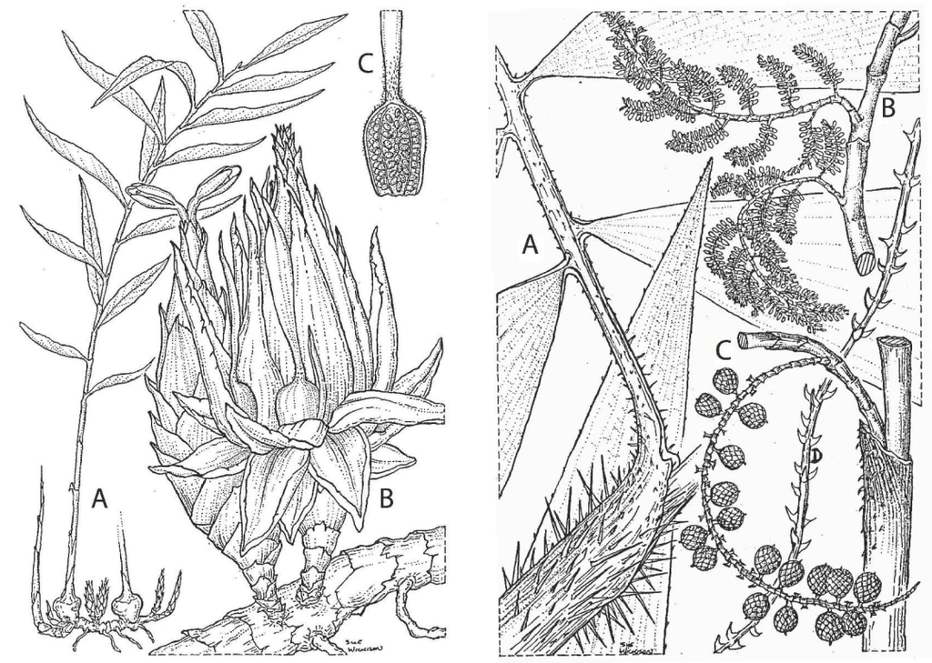

**Figure 7.11:** **Left** *Hornstedtia lycostoma*: **A**, plant, about 3 m high, with suckers and inflorescences; **B**, inflorescences; **C**, longitudinal section oflarge fruit. **Right** *Calamus hollrungii*, rattan: **A**, leaf base and spikes; **B**, inflorescence; **C**, fruit; **D**, portion of leaf tip with barbs.

Apparently none of the trees is used for timber, but Ann Chowning (pers. comm.) reports that on New Britain Nakanai and Meramera speakers dry *Laportea* bark over a fire and use it for roofs and walls. Wheatley (1992: 240) comments that *Dendrocnide moroides* (syn. *Laportea moroides*), a canopy tree of 25 m found in central Vanuatu, is considered useless because the wood is very soft and rots quickly. The leaves and bark of a number of species have medicinal uses. The leaves of a *Dendrocnide* species were used medicinally on Manam Island. They were boiled in water or with grated coconut to cure constipation or general seediness (Wedgwood 1934: 286–287). Peekel (1984: 151) notes that the finely chopped leaves of *Dendrocnide longifolia* (a shrub or small tree, 3-5m high) were mixed in to dogs’ food to make them hunt more keenly. *Dendrocnide latifolia* was used in much the same way on Mwotlap, except that here the recipients were warriors: they were given a soup made from the leaves to render them quicker tempered and stronger in battle (Wheatley 1992: 238).

Several forms below reflect PAn *lateŋ with a prefixed syllable: POc *ja-latoŋ, PAdm *la-latoŋ, *ña-latoŋ, PNCV *ga-latoŋ. The existence of the various prefixed forms indicates that unprefixed *latoŋ was also inherited into POc, and this is borne out by a single unprefixed reflex below: Kove *lato*. POc *jalatoŋ, the most widely reflected form, must also have been inherited, as non-Oceanic reflexes occur. Apart from a few languages in the extreme north of Vanuatu - Vures, Mwesen, Dorig, Merlav - which reflect the prefix *ja- regularly (François 2004b), most known reflexes in Vanuatu, listed separately below, reflect *ga- ‘tree’.

| **PAn** |  | *lateŋ | ‘stinging nettle tree, *Laportea harveyi*’ (Blust 1972b) |
| --- | --- | --- | --- |
| **PMP** |  | *zalateŋ | ‘*Laportea* and *Dendrocnide* spp.’ (Dempwolff 193 8) |
| **POc** |  | *[ja]latoŋ | ‘*Laportea* and *Dendrocnide* spp.’ (Milke 1961: *salatoŋ; Ross 1989b) |
| **PAdm** |  | *lalato, *ñalato | ‘*Laportea* and *Dendrocnide* spp.’ (Blust 1996b) |
| Adm | Lou | *lalat* | ‘*Laportea* and *Dendrocnide* spp.’ (Blust 1996b) |
| Adm | Wuvulu | *lalaʔo* | ‘*Laportea* and *Dendrocnide* spp.’ (Blust 1996b) |
| Adm | Kele | *lulat* | ‘*Laportea* and *Dendrocnide* spp.’ (Blust 1996b) |
| Adm | Lenkau | *lalatr* | ‘*Laportea* and *Dendrocnide* spp.’ (Blust 1996b) |
| Adm | Seimat | *nalat* | ‘*Laportea* and *Dendrocnide* spp.’ (Blust 1996b) |
| Adm | Bipi | *ñalak* | ‘*Laportea* and *Dendrocnide* spp.’ (Blust 1996b) |
| Adm | Loniu | *ñalat* | ‘*Laportea* and *Dendrocnide* spp.’ (Blust 1996b) |
| Adm | Leipon | *ñilet* | ‘*Laportea* and *Dendrocnide* spp.’ (Blust 1996b) |
| Adm | Drehet | *nolok* | ‘*Laportea* and *Dendrocnide* spp.’ (Blust 1996b) |
| **PWOc** |  | *[ja]latoŋ | ‘nettle tree, *Dendrocnide* sp., perhaps *Dendrocnide warburgii*’ |
| NNG | Kove | *lato* | ‘*Dendrocnide excelsa*’ (Chowning 2001: 83) |
| NNG | Takia | *dalat* | ‘nettle tree’ |
| NNG | Manam | *zalato* | ‘tree sp. which causes itching, cooked and eaten after maternity, used as a medicine’ |
| NNG | Sissano | *talat* | ‘nettle plant; poison oak tree’ |
| MM | Nduke | *zilatoŋo* | ‘*Laportea* interrupta and *Laportea ruderalis*’ |
| MM | Marovo | *zilatoŋo* | ‘*Laportea* interrupta and *Laportea ruderalis*’ |
| MM | Roviana | *jilatoŋo* | ‘k.o. nettle’ |
| **PEOc** |  | *[ja]lato | ‘nettle tree, *Dendrocnide* sp.’ |
| SES | Gela | *(haŋa)lato* | ‘*Dendrocnide* sp.’ (W. McClatchey, pers. comm.) |
| SES | Sa’a | *(nunu)lao* | ‘nettle tree’ |
| SES | Ulawa | *(dū)lao* | ‘nettle tree’ |
| SES | Arosi | *darao* | ‘k.o. nettle’ |
| NCV | Vurës | *silat* | ‘*Dendrocnide* sp.’ (François 2004b) |
| NCV | Mwesen | *salat* | ‘*Dendrocnide* sp.’ (François 2004b) |
| NCV | Dorig | *(o)slat* | ‘*Dendrocnide* sp.’ (François 2004b) |
| NCV | Merlav | *ne-silat* | ‘*Dendrocnide* sp.’ (François 2004b) |
| SV | Sye | *n-elyat* | ‘*Dendrocnide* sp.’ |
| Fij | Wayan | *salato* | ‘*Dendrocnide harveyi*’ (Geraghty 2004: 83) |
| Fij | Bauan | *salato* | ‘*Dendrocnide harveyi*’ (Geraghty 2004: 83) |
| Pn | Samoan | *salato* | ‘*Dendrocnide harveyi*’ (Whistler 2000: 196) |

| **PNCV** |  | *ga-lato | ‘nettle tree’ (Clark 1996) |
| --- | --- | --- | --- |
| NCV | Mwotlap | *na-hlat* | ‘*Dendrocnide* spp.’ |
| NCV | Mota | *kalato* | ‘nettle tree’ |
| NCV | Ambae | *kalato* | ‘*Dendrocnide latifolia*’ |
| NCV | Nokuku | *elat* | ‘nettle tree’ |
| NCV | Araki | *kalaro* | ‘*Dendrocnide* sp.’ |
| NCV | Tamambo | *(vu)kalato* | ‘nettle tree’ |
| NCV | Raga | *galato* | ‘*Dendrocnide latifolia*’ |
| NCV | Uripiv | *gelat* | ‘nettle trree’ |
| NCV | Labo | *na-ŋgalate* | ‘stinging nettle’ |
| NCV | Lonwolwol | *gela[r,t]* | ‘stinging leaf bush’ |

Clark (1996) plausibly suggests that PNCV *kara reflects POc *kaRat ‘bite’, and the final *-t* of Big Nambas *n-harat* appears to support this etymology.

| **POc** |  | *kara(t) | ‘a small stinging plant, perhaps *Laportea* interrupta’ (Chowning 2001: 83) |
| --- | --- | --- | --- |
| NNG | Kove | *gala* | ‘a stinging plant related to lato (*Dendrocnide excelsa*)?’ |
| MM | Tolai | *kara* | ‘stinging nettle spp., *Dendrocnide sessiliflora*, *Laportea interrupta*’ |
| NCV | Tape | *nə-xārət* | ‘stinging nettle’ |
| NCV | Big Nambas | *n-harət* | ‘stinging nettle’ |
| NCV | Port Sandwich | *na-xer* | ‘stinging nettle’ |
| NCV | Paamese | *a-ai* | ‘devil nettle (*Dendrocnide* sp.)’ |
| NCV | Lewo | *ke* | ‘nettle’ |
| NCV | Namakir | *kar* | ‘nettle tree’ |
| NCV | Nguna | *na-kara* | ‘nettle tree’ |

#### 6.3.3. *Lygodium* spp. (Lygodiaceae)

Ferns of the genus *Lygodium* are climbing vines which wind around tree trunks. Peekel (1984: 27, 30) writes that *Lygodium circinnatum* (syn. *L. dichotomum*, *Lygodium flexuosum*) grows 3-6m long, *Lygodium trifurcatum*, more delicate than *Lygodium circinnatum*, grows 3-5m high, and *Lygodium scandens* (syn. *L. microphyllum*) 1-3m long.

All are apparently used as binding material. The thicker *Lygodium circinnatum* and, among the Roviana, *Lygodium trifurcatum* are used for binding outrigger booms. The more delicate *Lygodium scandens* is used in weaving, for tying bundles and as circlets for the arm or leg (Waterhouse 1949, Arentz et al. 1989: 93).

| **PMP** |  | *qaRsam | ‘fern sp.’ (ACD) |
| --- | --- | --- | --- |
| **POc** |  | *qasam | ‘fern used for tying and binding, *Lygodium circinnatum*’ (ACD; Chowning 2001: 83) |
| MM | Nakanai | *hara* | ‘*Lygodium circinnatum*’ |
| MM | East Kara | *kasom* | ‘*Lygodium circinnatum*’ |
| MM | Patpatar | *sam* | ‘*Lygodium circinnatum*’ |
| MM | Patpatar | *sam-sam* | ‘*Lygodium scandens*’ |
| MM | Tolai | *em* | ‘*Lygodium circinnatum*’ |
| MM | Tolai | *em-ien* | ‘*Lygodium scandens*’ |
| MM | Tangga | *āsem* | ‘the *Lygodium* creeper’ |
| MM | Nehan | *heham* | ‘*Lygodium circinnatum*’ |
| MM | Petats | *aisam* | ‘*Lygodium circinnatum*’ |
| MM | Tinputz | *asam* | ‘*Lygodium circinnatum*’ (Blackwood 1935) |
| MM | Mono-Alu | *asama* | ‘a creeper species’ (Record 1945) |
| MM | Marovo | *amasa* | ‘creeping coastal fern, *Lygodium* sp. (metathesis)’ |
| MM | Roviana | *asama* | ‘a trailing fern, *Lygodium trifurcatum*’ |
| SES | Gela | *aha* | ‘species of creeper used for stringe’ |
| SES | Tolo | *asa* | ‘vine sp. used to bind canoes and weave baskets’ |
| SES | Kwara’ae | *sata* | ‘*Lygodium scandens*’ (Whitmore 1966) |

#### 6.3.4. *Merremia* spp. (Convolvulaceae)

*Merremia peltata* (syn. *Operculina peltata*, Convulvulus peltatus, *Ipomoea peltata*) is a woody liana found throughout the rain forest, but it is particularly abundant in disturbed forest areas. The vine has the thickness of a human arm and grows 15-50 m high, with white-yellowish funnel-shaped flowers that resemble Morning Glory (Peekel 1984:467, Pawley & Sayaba 2003, W. McClatchey, pers. comm.).

According to Peekel *Merremia peltata* vines are used as binding material in circumstances where the fastening does not need to be durable. Hviding (2005: 124) reports from Marovo that older thicker vines contain a milky sap that is good for stopping blood flow in an emergency.

| **POc** |  | *paliaRua | ‘a vine, *Merremia peltata*’ |
| --- | --- | --- | --- |
| MM | Nakanai | *valiala* | ‘a vine, *Ipomoea* sp.’ (Floyd 1954) |
| MM | East Kara | *viliai* | ‘*Merremia peltata*’ |
| MM | Madak | *leale* | ‘*Merremia peltata*’ |
| MM | Patpatar | *haliara* | ‘*Merremia peltata*’ |
| MM | Tolai | *valear[a,u]* | ‘*Merremia peltata*’ |
| MM | Ramoaaina | *waliara* | ‘a creeping plant’ |
| SV | Sye | *(nos-i)vilyau* | ‘*Merremia peltata*’ |
| Fij | Wayan | *veliawa* | ‘*Merremia peltata*’[^36] |

#### 6.3.5. *Asplenium nidus*, bird’s nest fern (Aspleniaceae)

The bird’s nest fern, *Asplenium nidus*, usually grows as an epiphyte on the trunks or branches of trees in the rain forest or mangrove swamp. It has large simple fronds visually similar to banana leaves, growing to 50-150cm long and 10–20cm broad. The fronds are light green, often crinkled, with a black midrib. The fronds grow in clusters and roll back as they turn brown, creating a massive leaf nest where they are attached to the tree. It is an ideal understorey plant, as it thrives in warm, humid habitats in partial or full shade (Peekel 1984: 17, Hviding 2005: 124).

The POc term was *pʷete.

| **POc** |  | *pʷete | ‘bird’s nest fern, *Asplenium nidus*’ |
| --- | --- | --- | --- |
| MM | Patpatar | *pate* | ‘*Asplenium nidus*’ |
| MM | Tolai | *pete* | ‘*Asplenium nidus*’ |
| NCV | Mota | *puɣet* | ‘*Asplenium nidus*’ |
| NCV | Dorig | *bıt* | ‘*Asplenium nidus*’ (François 2004b) |
| NCV | Lakon | *puıt* | ‘*Asplenium nidus*’ (François 2004b) |

## 7. The forest floor

Because it receives little light, the forest floor is often almost bare of plants that depend for their existence on photosynthesis. The lower parts of trees and the debris of fallen trunks and branches, however, provide a home for fungi of various kinds.

The generic term for mushrooms and fleshy fungi was POc *taliŋa (Ch 3, §4. 7), formally identical to *taliŋa ‘ear’ and presumably reflecting a perception that some fungi resemble the human ear. Blust (2000) points out that more detailed descriptions specify the referent of *taliŋa reflexes as jelly fungus, which do not have the umbrella-like shape of a mushroom but ‘sprout directly from the trunks of dead trees as a collection of folded tissues which may appear cup-like or ear-like’. Their names include reference to ‘ear’ in a number of cultures around the world. In Austronesian languages, including some in Oceania, the name also specifies the ear’s owner. Since they grow on tree bark, they are sometimes named ‘tree ear’. Whether one should therefore reconstruct POc *taliŋa qi kayu ‘tree fungus’ (lit. ‘ear of tree’) is a little debatable. This may well have been a POc locution, as Blust also notes its occurrence in non-Oceanic Austronesian languages, but it may also have been coined more than once in the history of Austronesian languages. Most of the terms below are from Blust (2000).

| Adm | Mondropolon | *can-n-i kei* | (*cane-n* ‘her/his ear’) |
| --- | --- | --- | --- |
| SV | Anejom̃ | *in-ticŋa-nɣai* | ‘mushroom (arboreal)’ (cf. *in-ɣai* ‘tree’) |
| Pn | Māori | *tariŋa rākau* |  |

Some jelly fungi are named ‘rat ear’, apparently because of their shape:

| NCV | Paamese | *raliŋe-n asu* | ‘kind of fungus which grows on dry wood’ |
| --- | --- | --- | --- |
| Mic | Marshallese | *lɔcilŋi-n kicṛik* | ‘toadstool, Auricularia ampla, and other ear-like Basidiomycetes (fungi)’ |
| Pn | Rarotongan | *tariŋa kiore* | ‘fungus sp. which grows on decaying trees’ |
| Pn | Tuamotuan | *tariŋa kiore* |  |
| Pn | Māori | *taliŋa ʔimoa* |  |

A number of Oceanic terms translate as ‘ghost ear’. Blust suggests that this reflects their spiritual significance, associated with the hallucinogenic properties of some fungi and with their sudden appearance after a thunder storm - which also accounts for the ‘thunder ear’ terms below. The distribution of ‘ghost ear’ terms perhaps justifies the reconstruction of POc *taliŋa qi qanitu, literally ‘ear of spirit of dead’, but the term for ‘spirit of dead’ varies across languages.

| Adm | Seimat | *taxiŋ i paxi* | (lit. ‘ear of ancestral spirit’) |
| --- | --- | --- | --- |
| Mic | Ponapean | *saleŋ en eni* |  |
| Mic | Mortlockese | *sᴂliŋa-n anu* | ‘mushroom’ (lit. ‘ear of ghost’) |
| Mic | Puluwatese | *hᴂliŋᴂ-n hoomᴂ* | ‘tree fungus, mushroom’ (*hoomᴂ* ‘bad ghost of dead’) |
| Mic | Chuukese | *seniŋe-r soomᴂ* |  |
| Fij | Rotuman | *faliaŋ ne ʔatua* | ‘toadstool or fungus’ |
| Fij | Bauan | *daliŋa ni kalou* |  |
| Pn | Tikopia | *tariŋa ŋa atua* |  |

The data below support a PMic reconstruction.

| **PMic** |  | *taliŋa ni para | ‘fungus growing on tree trunks’ (lit. ‘ear of thunder’) |
| --- | --- | --- | --- |
| Mic | Kiribati | *taniŋa ni pa* | ‘mushroom-like fungus growing on tree trunks, Myxomycetes: slime fungus’ (*ba* ‘thunder’) |
| Mic | Woleaian | *taliŋe-ɾi-pac̣* | ‘mushroom’ (*pac̣* ‘thunder’) |
| Mic | Satawalese | *saliŋa-ni-pac̣* | ‘kind of toadstool’ |

In our data sources terms for different kinds of fungus tend to be very few, and only one reconstruction is offered, based on work by French-Wright (1983).

| **PWOc** |  | *kokoi | ‘mushroom sp.’ (French-Wright 1983) |
| --- | --- | --- | --- |
| NNG | Kove | *koko* | ‘edible mushroom sp.’ (A. Chowning, pers. comm.) |
| PT | Bwaidoga | *kokoio* | ‘mushroom or toadstool sp.’ |
| MM | Petats | *koko* | ‘mushroom or toadstool’ |

## Notes

[^1]: Much of the primary forest with which this chapter is concerned has disappeared in the past quarter-century, logged and replaced by coconut, oil palm and timber plantations. Surveys conducted in 1993-94 indicated that the few remaining natural portions of lowland forest on New Britain’s north coast were in danger, and it was predicted that without active conservation all of the lowland forest of New Ireland would be selectively logged within a few years. There is already almost no primary forest left on the St Matthias Islands (World Wildlife Fund 2007b).
[^2]: This section owes much to Benders-Hyde (2000). The assignment of plants to the various layers in subsequent sections is largely due to Conn & Damas (2006).
[^3]: The reconstruction of PCEMP *bail ‘*Falcataria moluccana* or *Albizia* sp.’ is supported by the Oceanic data here, by Ambai (EMP, Yapen) *bai* ‘*Falcataria moluccana*’ (Price & Merasi n.d.), and by CMP items given by Verheijen (1990: 189): Far-east Manggarai (Lengkosambi) *wail*, Far-east Manggarai (Mulu) *fail*, Rembong *faé*, Rongga, Ngadha, Ende *fai*, Sika *(ai)béi*, Solorese *baé*, all *Albizia* chinensis.
[^4]: The reconstruction of PCEMP *ka(w)iak ‘*Albizia* sp.’ is supported by Nakanai (MM) *kai* and by CMP items given by Verheijen (1990: 189): Kepo, Razong, Rembong *kaé*, Waerana *kaék*, E Sumba *kawia[ka]*, all *Albizia* chinensis.
[^5]: It is absent from Henderson & Hancock (1988), Kwa’ioloa & Burt (2001) and Hviding (2005).
[^6]: They are *C. cassia*, Cassia cinnamon, *C. zeylanicum*, Ceylon cinnamon and *C. saigonicum*, Saigon cinnamon.
[^7]: The history of this confusion is recounted in the [September 2000 Newsletter of the company Essentially Oils](https://web.archive.org/web/20110501050250/http://www.essentiallyoils.com/Newsletters/2000/September_2000_Newsletter/september_2000_newsletter.html) citing Meijer (1940), who clarified the origins of the two oils.
[^8]: POc *-q- is lost in Are. I do not know how a Javanese term might have found its way into Are - perhaps the name arrived in New Guinea with traders and spread along with its valued denotatum.
[^9]: Geraghty (2004: 86–87) suggests that the Fijian form *makosoi* can be analysed as *mako* ‘a forest tree, Cyathocalyx sp.’ and *soi*, perhaps ‘cut’. In view of the cognate set given here it seems more likely that the Fijian form reflects metathesis, perhaps as a result of folk-etymologising. However, on this hypothesis Fijian *-s-* (for †*-ð-*) remains unexplained.
[^10]: Two tall *Dillenia* species, *D. papuana* and *D. montana* grow respectively in the lowlands of the southeast peninsula of New Guinea and in the highlands (Corm & Damas 2006). Another, *Dillenia salomonensis*, is reported from the Solomons (Kwa’ioloa & Burt 2001: 140, Hviding 2005: 120). The smaller *Dillenia biflora* is found in Vanuatu and in Fiji (Wheatley 1992: 790, Keppel et al. 2005).
[^11]: Final *-uy* is unexplained.
[^12]: Gardner & Pawley (2006) attribute the name to the fact that its leaves are ‘not unlike those of the breadfruit’, since it appears to be a reduplication of Wayan *kulu* ‘breadfruit’ (< POc *kuluR, ch, 9, §4). The Fijian forms reflect metathesis of the second and third vowels and this has perhaps generated a folk etymology associating the Wayan form with ‘breadfruit’.
[^13]: Proto Erakor-Tafea is the immediate putative ancestor of S Efate and Proto Southern Vanuatu.
[^14]: Peekel (1984: 313) incorrectly spells it *E. formicarium*.
[^15]: J. Parham (1972: 176) cites *manawi* as a Fijian name (dialect unspecified) for *Rhus* simarubaefolia, so the Wayan term is apparently representative of a pan-Fijian meaning shift.
[^16]: French (1986: 261) mentions that the black fruits, about 4cm in diameter, of several *Planchonella* species are sometimes eaten raw in Papua New Guinea but gives little detail. Unlike other authors, he says that the trees are planted from seed. Since most *Planchonella* species grow on mainland New Guinea and not in the Bismarcks, it is probable that his discussion relates to the mainland.
[^17]: Heyne (1950: 1315) lists a Ceram form *pasal* *Vitex cofassus* from an unnamed language, evidence that the POc form was an inheritance from PCEMP.
[^18]: In this instance Damon is describing a sample that has been brought to him: he notes that he has not seen the tree.
[^19]: The term *klambug* is apparently a term for a taxon which includes several *Dillenia* species.
[^20]: Proto South Melanesian is the putative ancestor of the Southern Vanuatu and New Caledonian languages (Lynch 2000c).
[^21]: The name is sometimes spelt Evodia.
[^22]: Such etymologising evidently did not occur in Western Oceanic or SE Solomonic languages: cf Kara (E) *ria*, Lihir *dala* and Kwara’ae *ʔabuan* ‘blood’. However, Marovo *juka-juka* ‘*Myristica* sp.’ (from *juka* ‘blood’, Hviding 2005: 118) also shows that the resemblance of *Myristica* sap to blood is widely recognised.
[^23]: A further complication is that most terms of the genus *Parinari* also have synonyms in which the genus is *Parinarium* and the species modifer has the Latin neuter gender. Hence, *Parinari laurina* = *Parinarium laurinum*. These synonyms are ignored here.
[^24]: Some recent sources prefer the term *Maranthes corymbosa*.
[^25]: Both *katita* and *tita* are recorded for Tolai.
[^26]: Polynesian terms reflect PPn *piu where †*fiu is expected.
[^27]: The spelling *nə-vha-vha* represents an attempt to interpret Wheatley’s (1992) *nawhawha* and is not necessarily accurate .
[^28]: In Motu POc *-l- > *-i-* before *i. Hence *bulu > *buiu > *biu, then (irregularly) > *bio*.
[^29]: However, I am inclined to doubt the accuracy of the gloss, since (i) Peekel does not list this species and (ii) herbarium specimens are all from Bougainville.
[^30]: But Hviding (2005: 107) does not give sufficient information to identify the species at Marovo.
[^31]: See also the discussion of some of the items in this cognate set in Chowning (2001).
[^32]: Wolff (1994) argues that this term should not be reconstructed for PMP as the non-Oceanic items have denotata unconnected with *Semecarpus forstenii*. However, the ACD includes Belau *ias* ‘*Excoecaria agallocha*’, a tree that also has toxic sap, thus supporting the PMP form.
[^33]: It is not clear whether POc *-w- was phonemic in this environment.
[^34]: Dioecious: a single plant is male or female. Monoecious: a single plant has reproductive units of both sexes.
[^35]: [Brisbane Rainforest Action and Information Network](https://web.archive.org/web/20070830025831/http://www.brisrain.webcentral.com.au/01_cms/details_pop.asp?ID=133), accessed 10 November 2007.
[^36]: J. Parham (1972) gives Fijian *veliyawa* ‘*Merremia pacifica*’ and *viliviwa* ‘*Merremia peltata*’ but does not name dialects.